# Banking Credit Risk Prediction

- Dataset : Give_me_some_credit
- Used to predict whether a new customer is credit worthy or not. Whether the bank should give him credit/loan or not.
- Students are instructed to open jupyter notebook.
- This is a hands on session

# Stages in ML Project

1. Problem statement/Goal/Objective
2. Data Exploration Validation
3. Data cleaning
4. Model Building and Validation

# problem statement

-Used to predict whether a new customer is credit worthy or not. Whether the bank/organization should give him credit/loan or not.

# import dataset

```python
import pandas as pd
import numpy as np
import matplotlib.pyplot as plt
import seaborn as sns

loans = pd.read_csv("https://raw.githubusercontent.com/venkatareddykonasani/Datasets/master/Give%20me%20some%20Credit/cs-training.csv")
loans.head()
```

|  | Sr_No | SeriousDlqin2yrs | monthly_utilization | age | NumberOfTime30-59DaysPastDueNotWorse | DebtRatio | MonthlyIncome | NumberOfOpenCreditLinesAndLoans | NumberOfTimes90DaysLate | NumberRealEstateLoansOrLines | NumberOfTime60-89DaysPastDueNotWorse | NumberOfDependents |
| --- | --- | --- | --- | --- | --- | --- | --- | --- | --- | --- | --- | --- |
| 0 | 1 | 1 | 0.766127 | 45 | 2 | 0.802982 | 9120.0 | 13 | 0 | 6 | 0 | 2.0 |
| 1 | 2 | 0 | 0.957151 | 40 | 0 | 0.121876 | 2600.0 | 4 | 0 | 0 | 0 | 1.0 |
| 2 | 3 | 0 | 0.658180 | 38 | 1 | 0.085113 | 3042.0 | 2 | 1 | 0 | 0 | 0.0 |
| 3 | 4 | 0 | 0.233810 | 30 | 0 | 0.036050 | 3300.0 | 5 | 0 | 0 | 0 | 0.0 |
| 4 | 5 | 0 | 0.907239 | 49 | 1 | 0.024926 | 63588.0 | 7 | 0 | 1 | 0 | 0.0 |

```python
loans.head(8)
```

|  | Sr_No | SeriousDlqin2yrs | monthly_utilization | age | NumberOfTime30-59DaysPastDueNotWorse | DebtRatio | MonthlyIncome | NumberOfOpenCreditLinesAndLoans | NumberOfTimes90DaysLate | NumberRealEstateLoansOrLines | NumberOfTime60-89DaysPastDueNotWorse | NumberOfDependents |
| --- | --- | --- | --- | --- | --- | --- | --- | --- | --- | --- | --- | --- |
| 0 | 1 | 1 | 0.766127 | 45 | 2 | 0.802982 | 9120.0 | 13 | 0 | 6 | 0 | 2.0 |
| 1 | 2 | 0 | 0.957151 | 40 | 0 | 0.121876 | 2600.0 | 4 | 0 | 0 | 0 | 1.0 |
| 2 | 3 | 0 | 0.658180 | 38 | 1 | 0.085113 | 3042.0 | 2 | 1 | 0 | 0 | 0.0 |
| 3 | 4 | 0 | 0.233810 | 30 | 0 | 0.036050 | 3300.0 | 5 | 0 | 0 | 0 | 0.0 |
| 4 | 5 | 0 | 0.907239 | 49 | 1 | 0.024926 | 63588.0 | 7 | 0 | 1 | 0 | 0.0 |
| 5 | 6 | 0 | 0.213179 | 74 | 0 | 0.375607 | 3500.0 | 3 | 0 | 1 | 0 | 1.0 |
| 6 | 7 | 0 | 0.305682 | 57 | 0 | 5710.000000 | NaN | 8 | 0 | 3 | 0 | 0.0 |
| 7 | 8 | 0 | 0.754464 | 39 | 0 | 0.209940 | 3500.0 | 8 | 0 | 0 | 0 | 0.0 |

```python
loans.info()
```

```
<class 'pandas.core.frame.DataFrame'>
RangeIndex: 150000 entries, 0 to 149999
Data columns (total 12 columns):
 #   Column                                Non-Null Count   Dtype
---  ------                                --------------   -----
 0   Sr_No                                 150000 non-null  int64
 1   SeriousDlqin2yrs                      150000 non-null  int64
 2   monthly_utilization                   150000 non-null  float64
 3   age                                   150000 non-null  int64
 4   NumberOfTime30-59DaysPastDueNotWorse  150000 non-null  int64
 5   DebtRatio                             150000 non-null  float64
 6   MonthlyIncome                         120269 non-null  float64
 7   NumberOfOpenCreditLinesAndLoans       150000 non-null  int64
 8   NumberOfTimes90DaysLate               150000 non-null  int64
 9   NumberRealEstateLoansOrLines          150000 non-null  int64
 10  NumberOfTime60-89DaysPastDueNotWorse  150000 non-null  int64
 11  NumberOfDependents                    146076 non-null  float64
dtypes: float64(4), int64(8)
memory usage: 13.7 MB
```

```python
loans.shape
```

```
(150000, 12)
```

```python
loans.shape[0]
```

```
150000
```

```python
loans.shape[1]
```

```
12
```

```python
loans.columns
```

```
Index(['Sr_No', 'SeriousDlqin2yrs', 'monthly_utilization', 'age',
       'NumberOfTime30-59DaysPastDueNotWorse', 'DebtRatio', 'MonthlyIncome',
       'NumberOfOpenCreditLinesAndLoans', 'NumberOfTimes90DaysLate',
       'NumberRealEstateLoansOrLines', 'NumberOfTime60-89DaysPastDueNotWorse',
       'NumberOfDependents'],
      dtype='object')
```

```python
# check the datatypes of each column
loans.dtypes
```

|  | 0 |
| --- | --- |
| Sr_No | int64 |
| SeriousDlqin2yrs | int64 |
| monthly_utilization | float64 |
| age | int64 |
| NumberOfTime30-59DaysPastDueNotWorse | int64 |
| DebtRatio | float64 |
| MonthlyIncome | float64 |
| NumberOfOpenCreditLinesAndLoans | int64 |
| NumberOfTimes90DaysLate | int64 |
| NumberRealEstateLoansOrLines | int64 |
| NumberOfTime60-89DaysPastDueNotWorse | int64 |
| NumberOfDependents | float64 |

**dtype:** object

- find null values in each column

```python
# find null values in each column.
loans.isnull()
```

|  | Sr_No | SeriousDlqin2yrs | monthly_utilization | age | NumberOfTime30-59DaysPastDueNotWorse | DebtRatio | MonthlyIncome | NumberOfOpenCreditLinesAndLoans | NumberOfTimes90DaysLate | NumberRealEstateLoansOrLines | NumberOfTime60-89DaysPastDueNotWorse | NumberOfDependents |
| --- | --- | --- | --- | --- | --- | --- | --- | --- | --- | --- | --- | --- |
| 0 | False | False | False | False | False | False | False | False | False | False | False | False |
| 1 | False | False | False | False | False | False | False | False | False | False | False | False |
| 2 | False | False | False | False | False | False | False | False | False | False | False | False |
| 3 | False | False | False | False | False | False | False | False | False | False | False | False |
| 4 | False | False | False | False | False | False | False | False | False | False | False | False |
| ... | ... | ... | ... | ... | ... | ... | ... | ... | ... | ... | ... | ... |
| 149995 | False | False | False | False | False | False | False | False | False | False | False | False |
| 149996 | False | False | False | False | False | False | False | False | False | False | False | False |
| 149997 | False | False | False | False | False | False | True | False | False | False | False | False |
| 149998 | False | False | False | False | False | False | False | False | False | False | False | False |
| 149999 | False | False | False | False | False | False | False | False | False | False | False | False |

150000 rows × 12 columns

```python
loans.isnull().sum()
```

|  | 0 |
| --- | --- |
| Sr_No | 0 |
| SeriousDlqin2yrs | 0 |
| monthly_utilization | 0 |
| age | 0 |
| NumberOfTime30-59DaysPastDueNotWorse | 0 |
| DebtRatio | 0 |
| MonthlyIncome | 29731 |
| NumberOfOpenCreditLinesAndLoans | 0 |
| NumberOfTimes90DaysLate | 0 |
| NumberRealEstateLoansOrLines | 0 |
| NumberOfTime60-89DaysPastDueNotWorse | 0 |
| NumberOfDependents | 3924 |

**dtype:** int64

```python
# number of missing values in entire dataframe
loans.isnull().sum().sum()
```

```
np.int64(33655)
```

# describe the dataframe

- it gives summary statistics of numerical columns.

```python
loans.describe()
```

|  | Sr_No | SeriousDlqin2yrs | monthly_utilization | age | NumberOfTime30-59DaysPastDueNotWorse | DebtRatio | MonthlyIncome | NumberOfOpenCreditLinesAndLoans | NumberOfTimes90DaysLate | NumberRealEstateLoansOrLines | NumberOfTime60-89DaysPastDueNotWorse | NumberOfDependents |
| --- | --- | --- | --- | --- | --- | --- | --- | --- | --- | --- | --- | --- |
| count | 150000.000000 | 150000.000000 | 150000.000000 | 150000.000000 | 150000.000000 | 150000.000000 | 1.202690e+05 | 150000.000000 | 150000.000000 | 150000.000000 | 150000.000000 | 146076.000000 |
| mean | 75000.500000 | 0.066840 | 6.048438 | 52.295207 | 0.421033 | 353.005076 | 6.670221e+03 | 8.452760 | 0.265973 | 1.018240 | 0.240387 | 0.757222 |
| std | 43301.414527 | 0.249746 | 249.755371 | 14.771866 | 4.192781 | 2037.818523 | 1.438467e+04 | 5.145951 | 4.169304 | 1.129771 | 4.155179 | 1.115086 |
| min | 1.000000 | 0.000000 | 0.000000 | 0.000000 | 0.000000 | 0.000000 | 0.000000e+00 | 0.000000 | 0.000000 | 0.000000 | 0.000000 | 0.000000 |
| 25% | 37500.750000 | 0.000000 | 0.029867 | 41.000000 | 0.000000 | 0.175074 | 3.400000e+03 | 5.000000 | 0.000000 | 0.000000 | 0.000000 | 0.000000 |
| 50% | 75000.500000 | 0.000000 | 0.154181 | 52.000000 | 0.000000 | 0.366508 | 5.400000e+03 | 8.000000 | 0.000000 | 1.000000 | 0.000000 | 0.000000 |
| 75% | 112500.250000 | 0.000000 | 0.559046 | 63.000000 | 0.000000 | 0.868254 | 8.249000e+03 | 11.000000 | 0.000000 | 2.000000 | 0.000000 | 1.000000 |
| max | 150000.000000 | 1.000000 | 50708.000000 | 109.000000 | 98.000000 | 329664.000000 | 3.008750e+06 | 58.000000 | 98.000000 | 54.000000 | 98.000000 | 20.000000 |

```python
loans.describe(percentiles=[0.25,0.5,0.75,0.90,0.95,0.99])
```

|  | Sr_No | SeriousDlqin2yrs | monthly_utilization | age | NumberOfTime30-59DaysPastDueNotWorse | DebtRatio | MonthlyIncome | NumberOfOpenCreditLinesAndLoans | NumberOfTimes90DaysLate | NumberRealEstateLoansOrLines | NumberOfTime60-89DaysPastDueNotWorse | NumberOfDependents |
| --- | --- | --- | --- | --- | --- | --- | --- | --- | --- | --- | --- | --- |
| count | 150000.000000 | 150000.000000 | 150000.000000 | 150000.000000 | 150000.000000 | 150000.000000 | 1.202690e+05 | 150000.000000 | 150000.000000 | 150000.000000 | 150000.000000 | 146076.000000 |
| mean | 75000.500000 | 0.066840 | 6.048438 | 52.295207 | 0.421033 | 353.005076 | 6.670221e+03 | 8.452760 | 0.265973 | 1.018240 | 0.240387 | 0.757222 |
| std | 43301.414527 | 0.249746 | 249.755371 | 14.771866 | 4.192781 | 2037.818523 | 1.438467e+04 | 5.145951 | 4.169304 | 1.129771 | 4.155179 | 1.115086 |
| min | 1.000000 | 0.000000 | 0.000000 | 0.000000 | 0.000000 | 0.000000 | 0.000000e+00 | 0.000000 | 0.000000 | 0.000000 | 0.000000 | 0.000000 |
| 25% | 37500.750000 | 0.000000 | 0.029867 | 41.000000 | 0.000000 | 0.175074 | 3.400000e+03 | 5.000000 | 0.000000 | 0.000000 | 0.000000 | 0.000000 |
| 50% | 75000.500000 | 0.000000 | 0.154181 | 52.000000 | 0.000000 | 0.366508 | 5.400000e+03 | 8.000000 | 0.000000 | 1.000000 | 0.000000 | 0.000000 |
| 75% | 112500.250000 | 0.000000 | 0.559046 | 63.000000 | 0.000000 | 0.868254 | 8.249000e+03 | 11.000000 | 0.000000 | 2.000000 | 0.000000 | 1.000000 |
| 90% | 135000.100000 | 0.000000 | 0.981278 | 72.000000 | 1.000000 | 1267.000000 | 1.166600e+04 | 15.000000 | 0.000000 | 2.000000 | 0.000000 | 2.000000 |
| 95% | 142500.050000 | 1.000000 | 1.000000 | 78.000000 | 2.000000 | 2449.000000 | 1.458760e+04 | 18.000000 | 1.000000 | 3.000000 | 1.000000 | 3.000000 |
| 99% | 148500.010000 | 1.000000 | 1.092956 | 87.000000 | 4.000000 | 4979.040000 | 2.500000e+04 | 24.000000 | 3.000000 | 4.000000 | 2.000000 | 4.000000 |
| max | 150000.000000 | 1.000000 | 50708.000000 | 109.000000 | 98.000000 | 329664.000000 | 3.008750e+06 | 58.000000 | 98.000000 | 54.000000 | 98.000000 | 20.000000 |

```python
loans.head(3).T
```

|  | 0 | 1 | 2 |
| --- | --- | --- | --- |
| Sr_No | 1.000000 | 2.000000 | 3.000000 |
| SeriousDlqin2yrs | 1.000000 | 0.000000 | 0.000000 |
| monthly_utilization | 0.766127 | 0.957151 | 0.658180 |
| age | 45.000000 | 40.000000 | 38.000000 |
| NumberOfTime30-59DaysPastDueNotWorse | 2.000000 | 0.000000 | 1.000000 |
| DebtRatio | 0.802982 | 0.121876 | 0.085113 |
| MonthlyIncome | 9120.000000 | 2600.000000 | 3042.000000 |
| NumberOfOpenCreditLinesAndLoans | 13.000000 | 4.000000 | 2.000000 |
| NumberOfTimes90DaysLate | 0.000000 | 0.000000 | 1.000000 |
| NumberRealEstateLoansOrLines | 6.000000 | 0.000000 | 0.000000 |
| NumberOfTime60-89DaysPastDueNotWorse | 0.000000 | 0.000000 | 0.000000 |
| NumberOfDependents | 2.000000 | 1.000000 | 0.000000 |

# Data Dictionary

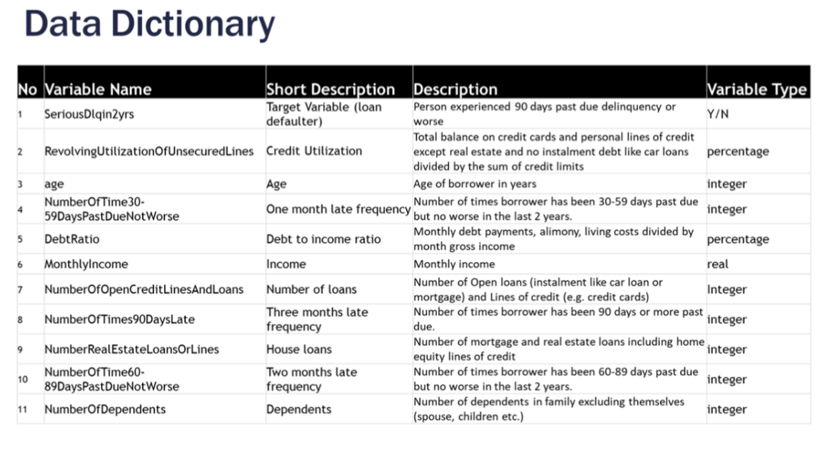

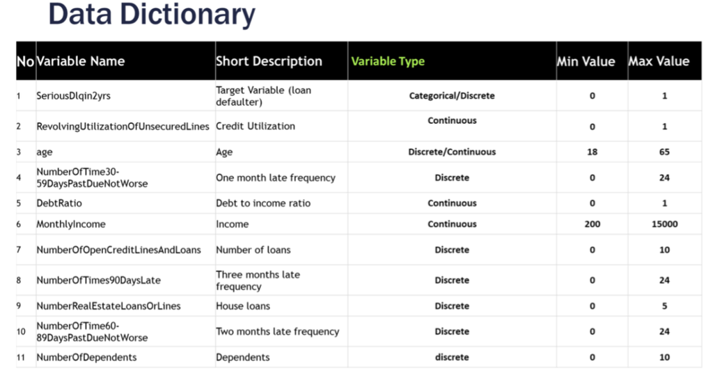

- mean and median of numeric columns

```python
loans.mean(numeric_only=True)
```

|  | 0 |
| --- | --- |
| Sr_No | 75000.500000 |
| SeriousDlqin2yrs | 0.066840 |
| monthly_utilization | 6.048438 |
| age | 52.295207 |
| NumberOfTime30-59DaysPastDueNotWorse | 0.421033 |
| DebtRatio | 353.005076 |
| MonthlyIncome | 6670.221237 |
| NumberOfOpenCreditLinesAndLoans | 8.452760 |
| NumberOfTimes90DaysLate | 0.265973 |
| NumberRealEstateLoansOrLines | 1.018240 |
| NumberOfTime60-89DaysPastDueNotWorse | 0.240387 |
| NumberOfDependents | 0.757222 |

**dtype:** float64

```python
loans.median(numeric_only=True)
```

|  | 0 |
| --- | --- |
| Sr_No | 75000.500000 |
| SeriousDlqin2yrs | 0.000000 |
| monthly_utilization | 0.154181 |
| age | 52.000000 |
| NumberOfTime30-59DaysPastDueNotWorse | 0.000000 |
| DebtRatio | 0.366508 |
| MonthlyIncome | 5400.000000 |
| NumberOfOpenCreditLinesAndLoans | 8.000000 |
| NumberOfTimes90DaysLate | 0.000000 |
| NumberRealEstateLoansOrLines | 1.000000 |
| NumberOfTime60-89DaysPastDueNotWorse | 0.000000 |
| NumberOfDependents | 0.000000 |

**dtype:** float64

- finding out difference between mean and median of numerical columns

```python
for col in loans.columns:
  print("--------------------------")
  print("The difference between mean and median for the column",col,"is", loans[col].mean() - loans[col].median())
```

```
--------------------------
The difference between mean and median for the column Sr_No is 0.0
--------------------------
The difference between mean and median for the column SeriousDlqin2yrs is 0.06684
--------------------------
The difference between mean and median for the column monthly_utilization is 5.894257317666888
--------------------------
The difference between mean and median for the column age is 0.2952066666666653
--------------------------
The difference between mean and median for the column NumberOfTime30-59DaysPastDueNotWorse is 0.4210333333333333
--------------------------
The difference between mean and median for the column DebtRatio is 352.63856792286987
--------------------------
The difference between mean and median for the column MonthlyIncome is 1270.2212373928442
--------------------------
The difference between mean and median for the column NumberOfOpenCreditLinesAndLoans is 0.4527599999999996
--------------------------
The difference between mean and median for the column NumberOfTimes90DaysLate is 0.26597333333333334
--------------------------
The difference between mean and median for the column NumberRealEstateLoansOrLines is 0.018240000000000034
--------------------------
The difference between mean and median for the column NumberOfTime60-89DaysPastDueNotWorse is 0.24038666666666667
--------------------------
The difference between mean and median for the column NumberOfDependents is 0.7572222678605657
```

- finding out number of unique values in each column

```python
# find number of unique values in each column
for col in loans.columns:
  print("--------------------------")
  print("The number of unique values for the column",col,"is", loans[col].nunique())
```

```
--------------------------
The number of unique values for the column Sr_No is 150000
--------------------------
The number of unique values for the column SeriousDlqin2yrs is 2
--------------------------
The number of unique values for the column monthly_utilization is 125728
--------------------------
The number of unique values for the column age is 86
--------------------------
The number of unique values for the column NumberOfTime30-59DaysPastDueNotWorse is 16
--------------------------
The number of unique values for the column DebtRatio is 114194
--------------------------
The number of unique values for the column MonthlyIncome is 13594
--------------------------
The number of unique values for the column NumberOfOpenCreditLinesAndLoans is 58
--------------------------
The number of unique values for the column NumberOfTimes90DaysLate is 19
--------------------------
The number of unique values for the column NumberRealEstateLoansOrLines is 28
--------------------------
The number of unique values for the column NumberOfTime60-89DaysPastDueNotWorse is 13
--------------------------
The number of unique values for the column NumberOfDependents is 13
```

# exploring the data

- explore categorical, discrete and continuous data.

**Discrete :**

- SeriousDlqin2yrs
- age
- NumberOfTime30-59DaysPastDueNotWorse
- NumberOfOpenCreditLinesAndLoans
- NumberOfTimes90DaysLate
- NumberRealEstateLoansOrLines
- NumberOfTime60-89DaysPastDueNotWorse
- NumberOfDependents

**Continuous :**

- monthly_utilization
- DebtRatio
- MonthlyIncome

**Nominal/Categorical :**

- No Nominal Variables
- a nominal variable is a type of data used to label or categorize things without assigning any numerical value or order

```python
loans.info()
```

```
<class 'pandas.core.frame.DataFrame'>
RangeIndex: 150000 entries, 0 to 149999
Data columns (total 12 columns):
 #   Column                                Non-Null Count   Dtype
---  ------                                --------------   -----
 0   Sr_No                                 150000 non-null  int64
 1   SeriousDlqin2yrs                      150000 non-null  int64
 2   monthly_utilization                   150000 non-null  float64
 3   age                                   150000 non-null  int64
 4   NumberOfTime30-59DaysPastDueNotWorse  150000 non-null  int64
 5   DebtRatio                             150000 non-null  float64
 6   MonthlyIncome                         120269 non-null  float64
 7   NumberOfOpenCreditLinesAndLoans       150000 non-null  int64
 8   NumberOfTimes90DaysLate               150000 non-null  int64
 9   NumberRealEstateLoansOrLines          150000 non-null  int64
 10  NumberOfTime60-89DaysPastDueNotWorse  150000 non-null  int64
 11  NumberOfDependents                    146076 non-null  float64
dtypes: float64(4), int64(8)
memory usage: 13.7 MB
```

# discrete variable explortion

- change datatype of numberofdependents, as it is a discrete value. change it from float to int

```python
loans['NumberOfDependents'].value_counts()
```

| NumberOfDependents | count |
| --- | --- |
| 0.0 | 86902 |
| 1.0 | 26316 |
| 2.0 | 19522 |
| 3.0 | 9483 |
| 4.0 | 2862 |
| 5.0 | 746 |
| 6.0 | 158 |
| 7.0 | 51 |
| 8.0 | 24 |
| 10.0 | 5 |
| 9.0 | 5 |
| 20.0 | 1 |
| 13.0 | 1 |

**dtype:** int64

```python
loans['NumberOfDependents'] = loans['NumberOfDependents'].astype('Int64')
loans['NumberOfDependents'].value_counts()
```

| NumberOfDependents | count |
| --- | --- |
| 0 | 86902 |
| 1 | 26316 |
| 2 | 19522 |
| 3 | 9483 |
| 4 | 2862 |
| 5 | 746 |
| 6 | 158 |
| 7 | 51 |
| 8 | 24 |
| 10 | 5 |
| 9 | 5 |
| 20 | 1 |
| 13 | 1 |

**dtype:** Int64

## Serious Delinquency

```python
loans['SeriousDlqin2yrs'].value_counts()
```

| SeriousDlqin2yrs | count |
| --- | --- |
| 0 | 139974 |
| 1 | 10026 |

**dtype:** int64

- The target variable gives us information about class imablance

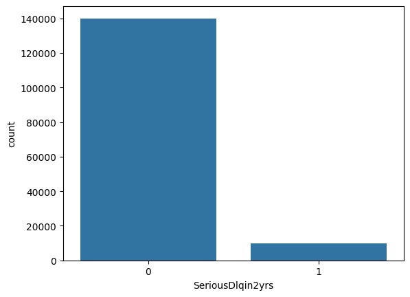

```python
sns.countplot(x = 'SeriousDlqin2yrs', data = loans)
```

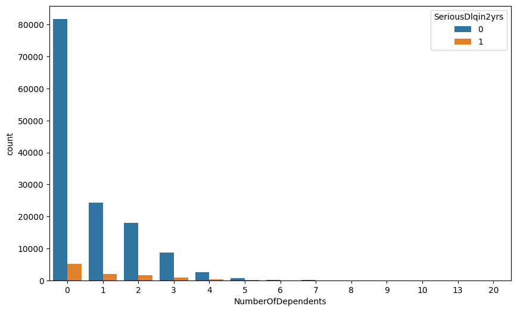

```python
plt.figure(figsize=(10,6))
sns.countplot(x='NumberOfDependents',hue = "SeriousDlqin2yrs",  data = loans )
plt.show()
```

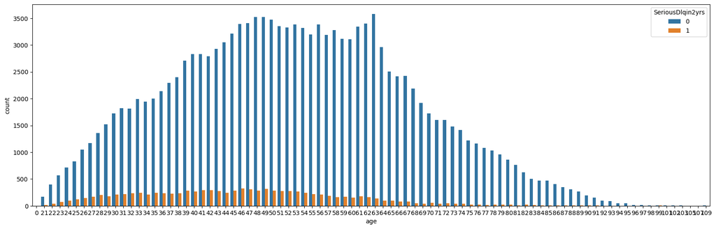

```python
plt.figure(figsize=(20,6))
sns.countplot(x='age',hue = "SeriousDlqin2yrs",  data = loans )
plt.show()
```

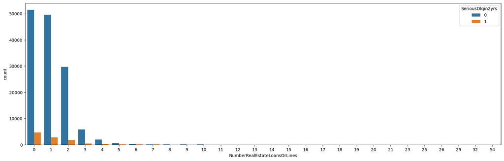

```python
plt.figure(figsize=(20,6))
sns.countplot(x='NumberRealEstateLoansOrLines',hue = "SeriousDlqin2yrs",  data = loans )
plt.show()
```

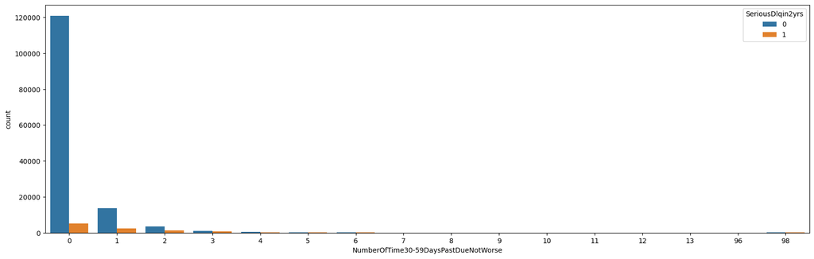

```python
plt.figure(figsize=(20,6))
sns.countplot(x='NumberOfTime30-59DaysPastDueNotWorse',hue = "SeriousDlqin2yrs",  data = loans )
plt.show()
```

```python
loans.columns
```

```
Index(['Sr_No', 'SeriousDlqin2yrs', 'monthly_utilization', 'age',
       'NumberOfTime30-59DaysPastDueNotWorse', 'DebtRatio', 'MonthlyIncome',
       'NumberOfOpenCreditLinesAndLoans', 'NumberOfTimes90DaysLate',
       'NumberRealEstateLoansOrLines', 'NumberOfTime60-89DaysPastDueNotWorse',
       'NumberOfDependents'],
      dtype='object')
```

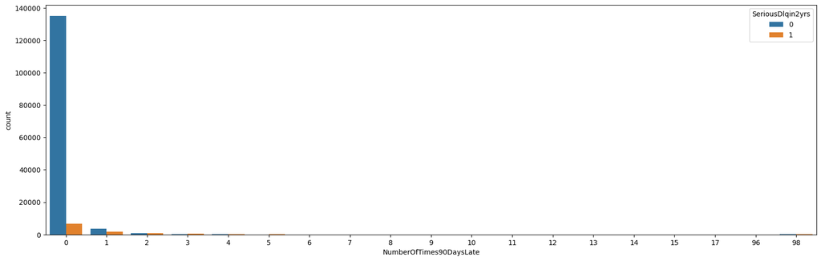

```python
plt.figure(figsize=(20,6))
sns.countplot(x='NumberOfTimes90DaysLate',hue = "SeriousDlqin2yrs",  data = loans )
plt.show()
```

- scatterplot

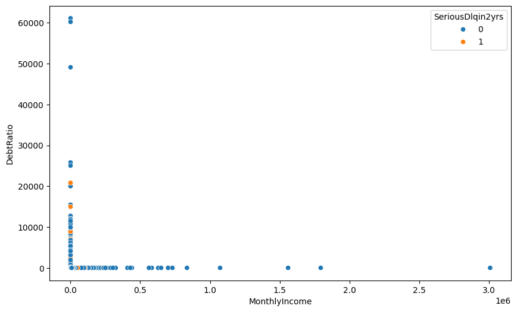

```python
plt.figure(figsize=(10,6))
sns.scatterplot(x = 'MonthlyIncome', y = 'DebtRatio', hue = 'SeriousDlqin2yrs', data = loans)
plt.show()
```

```python
loans['DebtRatio'].quantile([0.75,0.76,0.77,0.80])
```

|  | DebtRatio |
| --- | --- |
| 0.75 | 0.868254 |
| 0.76 | 0.951184 |
| 0.77 | 1.058832 |
| 0.80 | 4.000000 |

**dtype:** float64

```python
loans['MonthlyIncome'].quantile([0.75,0.76,0.8,0.90,0.97,0.99])
```

|  | MonthlyIncome |
| --- | --- |
| 0.75 | 8249.0 |
| 0.76 | 8350.0 |
| 0.80 | 9083.0 |
| 0.90 | 11666.0 |
| 0.97 | 17000.0 |
| 0.99 | 25000.0 |

**dtype:** float64

## Age

```python
loans['age'].value_counts()
```

| age | count |
| --- | --- |
| 49 | 3837 |
| 48 | 3806 |
| 50 | 3753 |
| 47 | 3719 |
| 63 | 3719 |
| ... | ... |
| 102 | 3 |
| 109 | 2 |
| 107 | 1 |
| 105 | 1 |
| 0 | 1 |

86 rows × 1 columns

**dtype:** int64

```python
loans['age'].quantile([0.75,0.76,0.8,0.90,0.97,0.99])
```

|  | age |
| --- | --- |
| 0.75 | 63.0 |
| 0.76 | 63.0 |
| 0.80 | 65.0 |
| 0.90 | 72.0 |
| 0.97 | 81.0 |
| 0.99 | 87.0 |

**dtype:** float64

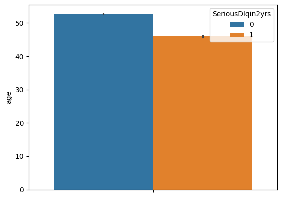

```python
sns.barplot(loans,y='age',hue='SeriousDlqin2yrs')
```

- In barplot, the scale on y-axis is average. so in this figure, the average is given.

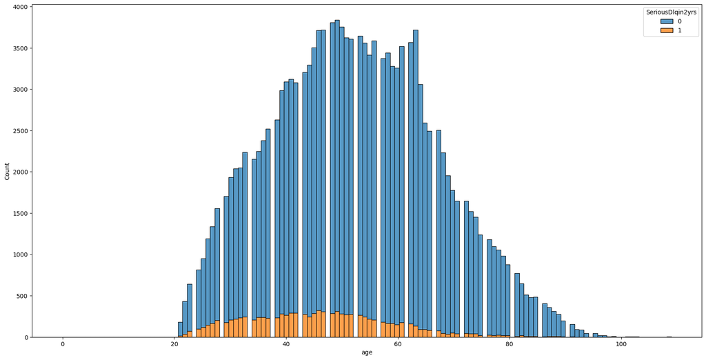

```python
plt.figure(figsize=(20,10))
sns.histplot(loans,x='age',hue='SeriousDlqin2yrs',multiple='stack')
plt.show()
```

## one month delay

```python
loans.columns
```

```
Index(['Sr_No', 'SeriousDlqin2yrs', 'monthly_utilization', 'age',
       'NumberOfTime30-59DaysPastDueNotWorse', 'DebtRatio', 'MonthlyIncome',
       'NumberOfOpenCreditLinesAndLoans', 'NumberOfTimes90DaysLate',
       'NumberRealEstateLoansOrLines', 'NumberOfTime60-89DaysPastDueNotWorse',
       'NumberOfDependents'],
      dtype='object')
```

```python
loans['NumberOfTime30-59DaysPastDueNotWorse'].value_counts()
```

| NumberOfTime30-59DaysPastDueNotWorse | count |
| --- | --- |
| 0 | 126018 |
| 1 | 16033 |
| 2 | 4598 |
| 3 | 1754 |
| 4 | 747 |
| 5 | 342 |
| 98 | 264 |
| 6 | 140 |
| 7 | 54 |
| 8 | 25 |
| 9 | 12 |
| 96 | 5 |
| 10 | 4 |
| 12 | 2 |
| 13 | 1 |
| 11 | 1 |

**dtype:** int64

```python
loans['NumberOfTime30-59DaysPastDueNotWorse'].quantile([0.75,0.76,0.8,0.90,0.97,0.99,0.999])
```

|  | NumberOfTime30-59DaysPastDueNotWorse |
| --- | --- |
| 0.750 | 0.0 |
| 0.760 | 0.0 |
| 0.800 | 0.0 |
| 0.900 | 1.0 |
| 0.970 | 2.0 |
| 0.990 | 4.0 |
| 0.999 | 98.0 |

**dtype:** float64

## number of open credit loans

```python
loans['NumberOfOpenCreditLinesAndLoans'].value_counts()
```

| NumberOfOpenCreditLinesAndLoans | count |
| --- | --- |
| 6 | 13614 |
| 7 | 13245 |
| 5 | 12931 |
| 8 | 12562 |
| 4 | 11609 |
| 9 | 11355 |
| 10 | 9624 |
| 3 | 9058 |
| 11 | 8321 |
| 12 | 7005 |
| 2 | 6666 |
| 13 | 5667 |
| 14 | 4546 |
| 1 | 4438 |
| 15 | 3645 |
| 16 | 3000 |
| 17 | 2370 |
| 0 | 1888 |
| 18 | 1874 |
| 19 | 1433 |
| 20 | 1169 |
| 21 | 864 |
| 22 | 685 |
| 23 | 533 |
| 24 | 422 |
| 25 | 337 |
| 26 | 239 |
| 27 | 194 |
| 28 | 150 |
| 29 | 114 |
| 30 | 88 |
| 31 | 74 |
| 32 | 52 |
| 33 | 47 |
| 34 | 35 |
| 35 | 27 |
| 36 | 18 |
| 38 | 13 |
| 40 | 10 |
| 39 | 9 |
| 43 | 8 |
| 42 | 8 |
| 45 | 8 |
| 37 | 7 |
| 48 | 6 |
| 54 | 4 |
| 49 | 4 |
| 41 | 4 |
| 46 | 3 |
| 52 | 3 |
| 47 | 2 |
| 51 | 2 |
| 57 | 2 |
| 56 | 2 |
| 44 | 2 |
| 50 | 2 |
| 58 | 1 |
| 53 | 1 |

**dtype:** int64

```python
loans['NumberOfOpenCreditLinesAndLoans'].quantile([0.75,0.76,0.8,0.90,0.97,0.99,0.999])
```

|  | NumberOfOpenCreditLinesAndLoans |
| --- | --- |
| 0.750 | 11.0 |
| 0.760 | 11.0 |
| 0.800 | 12.0 |
| 0.900 | 15.0 |
| 0.970 | 20.0 |
| 0.990 | 24.0 |
| 0.999 | 34.0 |

**dtype:** float64

## three month delay

```python
loans['NumberOfTimes90DaysLate'].value_counts()
```

| NumberOfTimes90DaysLate | count |
| --- | --- |
| 0 | 141662 |
| 1 | 5243 |
| 2 | 1555 |
| 3 | 667 |
| 4 | 291 |
| 98 | 264 |
| 5 | 131 |
| 6 | 80 |
| 7 | 38 |
| 8 | 21 |
| 9 | 19 |
| 10 | 8 |
| 96 | 5 |
| 11 | 5 |
| 13 | 4 |
| 15 | 2 |
| 14 | 2 |
| 12 | 2 |
| 17 | 1 |

**dtype:** int64

```python
loans['NumberOfTimes90DaysLate'].quantile([0.75,0.76,0.8,0.90,0.97,0.99,0.999])
```

|  | NumberOfTimes90DaysLate |
| --- | --- |
| 0.750 | 0.0 |
| 0.760 | 0.0 |
| 0.800 | 0.0 |
| 0.900 | 0.0 |
| 0.970 | 1.0 |
| 0.990 | 3.0 |
| 0.999 | 98.0 |

**dtype:** float64

## number of real estate loans

```python
loans['NumberRealEstateLoansOrLines'].value_counts()
```

| NumberRealEstateLoansOrLines | count |
| --- | --- |
| 0 | 56188 |
| 1 | 52338 |
| 2 | 31522 |
| 3 | 6300 |
| 4 | 2170 |
| 5 | 689 |
| 6 | 320 |
| 7 | 171 |
| 8 | 93 |
| 9 | 78 |
| 10 | 37 |
| 11 | 23 |
| 12 | 18 |
| 13 | 15 |
| 14 | 7 |
| 15 | 7 |
| 17 | 4 |
| 16 | 4 |
| 25 | 3 |
| 23 | 2 |
| 20 | 2 |
| 19 | 2 |
| 18 | 2 |
| 26 | 1 |
| 21 | 1 |
| 54 | 1 |
| 29 | 1 |
| 32 | 1 |

**dtype:** int64

```python
loans['NumberRealEstateLoansOrLines'].quantile([0.75,0.76,0.8,0.90,0.97,0.99,0.999])
```

|  | NumberRealEstateLoansOrLines |
| --- | --- |
| 0.750 | 2.0 |
| 0.760 | 2.0 |
| 0.800 | 2.0 |
| 0.900 | 2.0 |
| 0.970 | 3.0 |
| 0.990 | 4.0 |
| 0.999 | 9.0 |

**dtype:** float64

## two months delay

```python
loans.columns
```

```
Index(['Sr_No', 'SeriousDlqin2yrs', 'monthly_utilization', 'age',
       'NumberOfTime30-59DaysPastDueNotWorse', 'DebtRatio', 'MonthlyIncome',
       'NumberOfOpenCreditLinesAndLoans', 'NumberOfTimes90DaysLate',
       'NumberRealEstateLoansOrLines', 'NumberOfTime60-89DaysPastDueNotWorse',
       'NumberOfDependents'],
      dtype='object')
```

```python
loans['NumberOfTime60-89DaysPastDueNotWorse'].value_counts()
```

| NumberOfTime60-89DaysPastDueNotWorse | count |
| --- | --- |
| 0 | 142396 |
| 1 | 5731 |
| 2 | 1118 |
| 3 | 318 |
| 98 | 264 |
| 4 | 105 |
| 5 | 34 |
| 6 | 16 |
| 7 | 9 |
| 96 | 5 |
| 8 | 2 |
| 11 | 1 |
| 9 | 1 |

**dtype:** int64

```python
loans['NumberOfTime60-89DaysPastDueNotWorse'].quantile([0.75,0.76,0.8,0.90,0.97,0.99,0.999])
```

|  | NumberOfTime60-89DaysPastDueNotWorse |
| --- | --- |
| 0.750 | 0.0 |
| 0.760 | 0.0 |
| 0.800 | 0.0 |
| 0.900 | 0.0 |
| 0.970 | 1.0 |
| 0.990 | 2.0 |
| 0.999 | 98.0 |

**dtype:** float64

## number of dependents

```python
loans['NumberOfDependents'].value_counts()
```

| NumberOfDependents | count |
| --- | --- |
| 0 | 86902 |
| 1 | 26316 |
| 2 | 19522 |
| 3 | 9483 |
| 4 | 2862 |
| 5 | 746 |
| 6 | 158 |
| 7 | 51 |
| 8 | 24 |
| 10 | 5 |
| 9 | 5 |
| 20 | 1 |
| 13 | 1 |

**dtype:** Int64

```python
loans['NumberOfDependents'].quantile([0.75,0.76,0.8,0.90,0.97,0.99,0.999])
```

|  | NumberOfDependents |
| --- | --- |
| 0.750 | 1 |
| 0.760 | 1 |
| 0.800 | 2 |
| 0.900 | 2 |
| 0.970 | 3 |
| 0.990 | 4 |
| 0.999 | 6 |

**dtype:** Int64

# continuous variable exploration

## credit utilization

- column name in the dataframe in monthly utilization

```
{'whiskers': [<matplotlib.lines.Line2D at 0x7ca9f2f6ca40>,
 'caps': [<matplotlib.lines.Line2D at 0x7ca9f2f6d010>,
 'boxes': [<matplotlib.lines.Line2D at 0x7ca9f37778f0>],
 'medians': [<matplotlib.lines.Line2D at 0x7ca9f2f6d520>],
 'fliers': [<matplotlib.lines.Line2D at 0x7ca9f2f6d700>],
 'means': []}
```

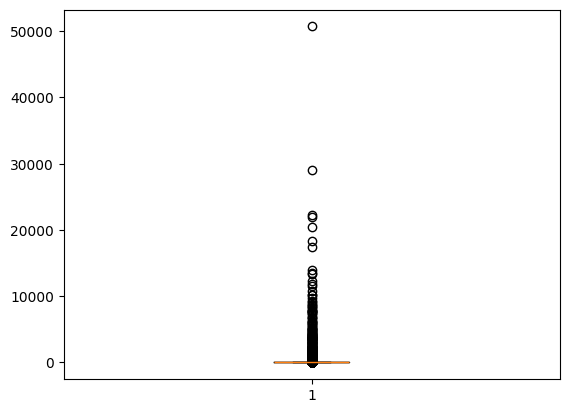

```python
plt.boxplot(loans['monthly_utilization'])
```

```python
loans['monthly_utilization'].sample(5)
```

|  | monthly_utilization |
| --- | --- |
| 290 | 0.191002 |
| 40319 | 0.733886 |
| 129185 | 0.438840 |
| 96476 | 0.120988 |
| 143425 | 0.172166 |

**dtype:** float64

```python
loans['monthly_utilization'].quantile([0, 0.1, 0.2,0.3,0.4, 0.5, 0.75, 0.80, 0.9,0.91,0.95,0.96,0.97,0.975,0.98,0.99,1])
```

|  | monthly_utilization |
| --- | --- |
| 0.000 | 0.000000 |
| 0.100 | 0.002969 |
| 0.200 | 0.019222 |
| 0.300 | 0.043461 |
| 0.400 | 0.083181 |
| 0.500 | 0.154181 |
| 0.750 | 0.559046 |
| 0.800 | 0.698857 |
| 0.900 | 0.981278 |
| 0.910 | 1.000000 |
| 0.950 | 1.000000 |
| 0.960 | 1.000000 |
| 0.970 | 1.000000 |
| 0.975 | 1.000000 |
| 0.980 | 1.006199 |
| 0.990 | 1.092956 |
| 1.000 | 50708.000000 |

**dtype:** float64

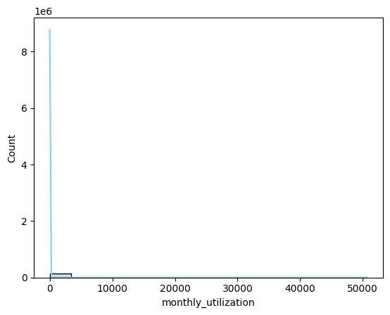

```python
sns.histplot(loans['monthly_utilization'],bins=15,kde=True,color='skyblue')
```

## debt ratio

```
{'whiskers': [<matplotlib.lines.Line2D at 0x7ca9f2ab5fa0>,
 'caps': [<matplotlib.lines.Line2D at 0x7ca9f2ab6570>,
 'boxes': [<matplotlib.lines.Line2D at 0x7ca9f3656e70>],
 'medians': [<matplotlib.lines.Line2D at 0x7ca9f2ab6b10>],
 'fliers': [<matplotlib.lines.Line2D at 0x7ca9f2ab6e10>],
 'means': []}
```

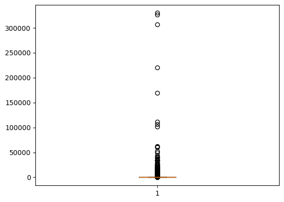

```python
plt.boxplot(loans['DebtRatio'])
```

```python
loans['DebtRatio'].quantile([0, 0.1, 0.2,0.3,0.4, 0.5, 0.75, 0.80, 0.9,0.91,0.95,0.96,0.97,0.975,0.98,0.99,1])
```

|  | DebtRatio |
| --- | --- |
| 0.000 | 0.000000 |
| 0.100 | 0.030874 |
| 0.200 | 0.133773 |
| 0.300 | 0.213697 |
| 0.400 | 0.287460 |
| 0.500 | 0.366508 |
| 0.750 | 0.868254 |
| 0.800 | 4.000000 |
| 0.900 | 1267.000000 |
| 0.910 | 1462.000000 |
| 0.950 | 2449.000000 |
| 0.960 | 2791.000000 |
| 0.970 | 3225.000000 |
| 0.975 | 3489.025000 |
| 0.980 | 3839.000000 |
| 0.990 | 4979.040000 |
| 1.000 | 329664.000000 |

**dtype:** float64

```python
loans['DebtRatio'].quantile([ 0.75,0.76,0.77,0.78,0.79, 0.80, 0.9,0.99,1])
```

|  | DebtRatio |
| --- | --- |
| 0.75 | 0.868254 |
| 0.76 | 0.951184 |
| 0.77 | 1.058832 |
| 0.78 | 1.275069 |
| 0.79 | 1.759204 |
| 0.80 | 4.000000 |
| 0.90 | 1267.000000 |
| 0.99 | 4979.040000 |
| 1.00 | 329664.000000 |

**dtype:** float64

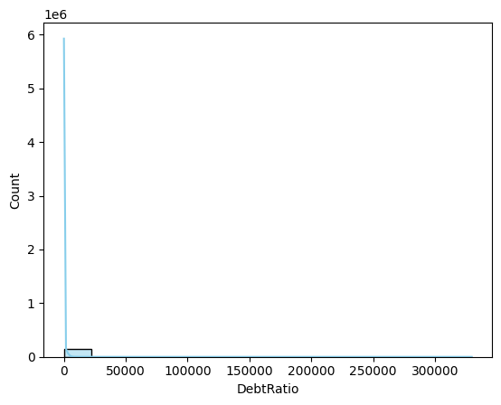

```python
sns.histplot(loans['DebtRatio'],bins=15,kde=True,color='skyblue')
```

## monthly income

```
{'whiskers': [<matplotlib.lines.Line2D at 0x7ca9f29bde50>,
 'caps': [<matplotlib.lines.Line2D at 0x7ca9f29be480>,
 'boxes': [<matplotlib.lines.Line2D at 0x7ca9f29bdb80>],
 'medians': [<matplotlib.lines.Line2D at 0x7ca9f29bea50>],
 'fliers': [<matplotlib.lines.Line2D at 0x7ca9f29bec90>],
 'means': []}
```

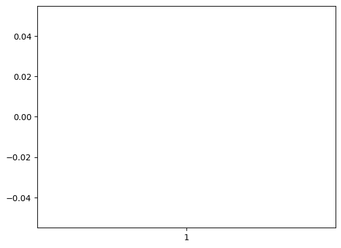

```python
plt.boxplot(loans['MonthlyIncome'])  # monthly income has null values. thats why there is an issue with boxplot.
```

```python
loans.isnull().sum() #
```

|  | 0 |
| --- | --- |
| Sr_No | 0 |
| SeriousDlqin2yrs | 0 |
| monthly_utilization | 0 |
| age | 0 |
| NumberOfTime30-59DaysPastDueNotWorse | 0 |
| DebtRatio | 0 |
| MonthlyIncome | 29731 |
| NumberOfOpenCreditLinesAndLoans | 0 |
| NumberOfTimes90DaysLate | 0 |
| NumberRealEstateLoansOrLines | 0 |
| NumberOfTime60-89DaysPastDueNotWorse | 0 |
| NumberOfDependents | 3924 |

**dtype:** int64

```
{'whiskers': [<matplotlib.lines.Line2D at 0x7ca9f29777d0>,
 'caps': [<matplotlib.lines.Line2D at 0x7ca9f2977dd0>,
 'boxes': [<matplotlib.lines.Line2D at 0x7ca9f2977560>],
 'medians': [<matplotlib.lines.Line2D at 0x7ca9f2900410>],
 'fliers': [<matplotlib.lines.Line2D at 0x7ca9f29006b0>],
 'means': []}
```

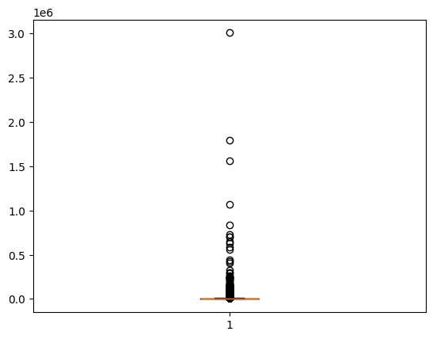

```python
# conside only non null values
non_null_monthly = loans['MonthlyIncome'][loans['MonthlyIncome'].isnull()==False]
plt.boxplot(non_null_monthly)
```

## Steps for exploration

- used to identify outliers
- 1. for each column,see if there are null values or not
  2. Then get statistical summary/observation regarding outliers. Use value_counts(),quantile(),nunique(), visualizations to obtain statistical obersvations
  3. Combine this with business knowledge to determine the threshold for outliers.
- If there are null values, then boxplot will be empty. So, extract all non null values, then plot the boxplot.

# Data cleaning

- for both less than 10% and between 10 and 50% , always create a new variable

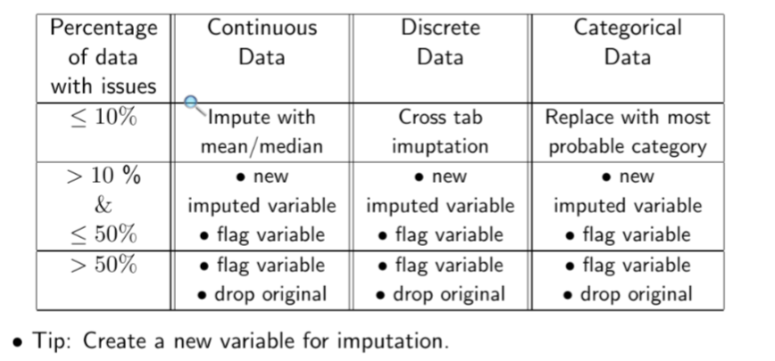

- Create this table

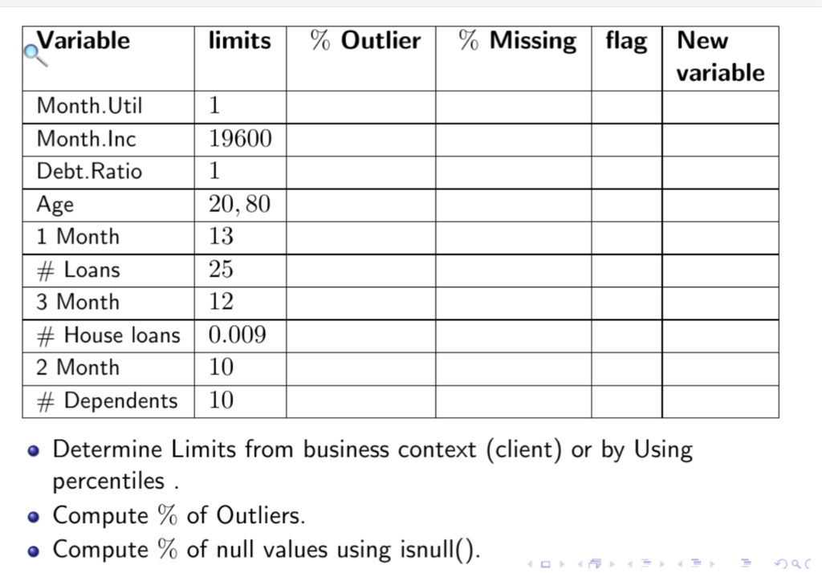

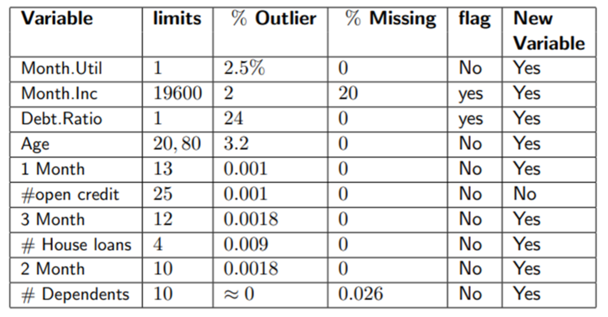

- finding percentage of missing values in monthly income

```python
round(loans['MonthlyIncome'].isnull().sum()/len(loans),2)*100
```

```
np.float64(20.0)
```

```python
# finding percentage of missing values in MonthlyIncome
missing_monthly_income_percentage = (loans['MonthlyIncome'].isnull().sum() / len(loans)) * 100
print(f"Percentage of missing values in 'MonthlyIncome': {missing_monthly_income_percentage:.2f}%")
```

```
Percentage of missing values in 'MonthlyIncome': 19.82%
```

- finding percentage of outliers for monthly utilization

```python
loans.loc[loans['monthly_utilization'] > 1].shape[0]
```

```
3321
```

```python
# finding percentage of values greater than one in 'monthly_utilization'
monthly_utilization_outliers_percentage = (loans.loc[loans['monthly_utilization'] > 1].shape[0] / len(loans)) * 100
print(f"Percentage of values greater than 1 in 'monthly_utilization': {monthly_utilization_outliers_percentage:.2f}%")
```

```
Percentage of values greater than 1 in 'monthly_utilization': 2.21%
```

# Cleaning of continuous variables

- keep clean data as it is
- impute unclean data

## credit utilization

```python
median_util = loans['monthly_utilization'].median()
print(median_util)
```

```
0.154180737
```

```python
# create a new column for imputation
loans['cred_util_new'] = loans['monthly_utilization']
loans.loc[loans['monthly_utilization'] > 1, 'cred_util_new'] = median_util
```

```python
loans['monthly_utilization'].quantile([0, 0.1, 0.2,0.3,0.4, 0.5, 0.75, 0.80, 0.9,0.91,0.95,0.96,0.97,0.975,0.98,0.99,1])
```

|  | monthly_utilization |
| --- | --- |
| 0.000 | 0.000000 |
| 0.100 | 0.002969 |
| 0.200 | 0.019222 |
| 0.300 | 0.043461 |
| 0.400 | 0.083181 |
| 0.500 | 0.154181 |
| 0.750 | 0.559046 |
| 0.800 | 0.698857 |
| 0.900 | 0.981278 |
| 0.910 | 1.000000 |
| 0.950 | 1.000000 |
| 0.960 | 1.000000 |
| 0.970 | 1.000000 |
| 0.975 | 1.000000 |
| 0.980 | 1.006199 |
| 0.990 | 1.092956 |
| 1.000 | 50708.000000 |

**dtype:** float64

```python
loans['cred_util_new'].quantile([0, 0.1, 0.2,0.3,0.4, 0.5, 0.75, 0.80, 0.9,0.91,0.95,0.96,0.97,0.975,0.98,0.99,1])
```

|  | cred_util_new |
| --- | --- |
| 0.000 | 0.000000 |
| 0.100 | 0.002969 |
| 0.200 | 0.019222 |
| 0.300 | 0.043461 |
| 0.400 | 0.083181 |
| 0.500 | 0.154178 |
| 0.750 | 0.506929 |
| 0.800 | 0.634723 |
| 0.900 | 0.930559 |
| 0.910 | 0.954839 |
| 0.950 | 1.000000 |
| 0.960 | 1.000000 |
| 0.970 | 1.000000 |
| 0.975 | 1.000000 |
| 0.980 | 1.000000 |
| 0.990 | 1.000000 |
| 1.000 | 1.000000 |

**dtype:** float64

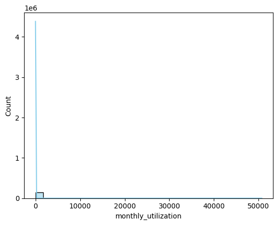

```python
sns.histplot(loans['monthly_utilization'],bins=30,kde=True,color='skyblue')
```

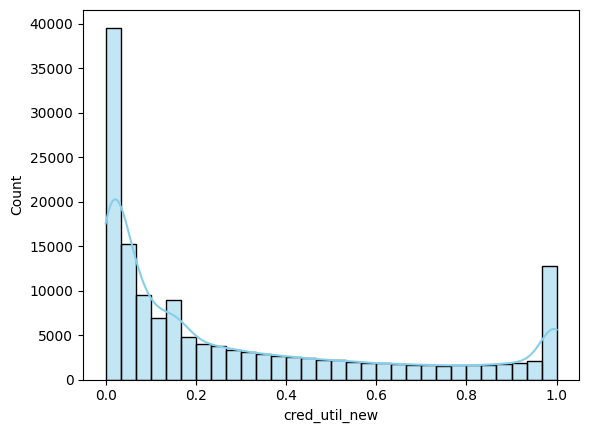

```python
sns.histplot(loans['cred_util_new'],bins=30,kde=True,color='skyblue')
```

## Montly Income

```python
# the number of missing values in this column are
loans['MonthlyIncome'].isnull().sum()
```

```
np.int64(29731)
```

```python
# percentage of missing values
loans['MonthlyIncome'].isnull().sum()/len(loans['MonthlyIncome']) * 100
```

```
np.float64(19.820666666666668)
```

- create a flag variable

```python
loans['MonthlyIncome_ind'] = 1
loans.loc[loans['MonthlyIncome'].isnull(),'MonthlyIncome_ind']=0
loans['MonthlyIncome_ind'].value_counts()
```

| MonthlyIncome_ind | count |
| --- | --- |
| 1 | 120269 |
| 0 | 29731 |

**dtype:** int64

- Impute

```python
loans['MonthlyIncome_new'] = loans['MonthlyIncome']
loans.loc[loans['MonthlyIncome'].isnull(), 'MonthlyIncome_new'] = loans['MonthlyIncome'].median()
```

```python
loans['MonthlyIncome_new'].isnull().sum()
```

```
np.int64(0)
```

## debt ratio

- 24% of data is outliers
- create a flag variable

```python
loans['DebtRatio_ind'] = 1
loans.loc[loans['DebtRatio'] > 1, 'DebtRatio_ind'] = 0
```

```python
loans['DebtRatio_ind'].value_counts()
```

| DebtRatio_ind | count |
| --- | --- |
| 1 | 114863 |
| 0 | 35137 |

**dtype:** int64

- impute with median

```python
loans['DebtRatio_new'] = loans['DebtRatio']
loans.loc[loans['DebtRatio'] > 1, 'DebtRatio_new'] = loans['DebtRatio'].median()
```

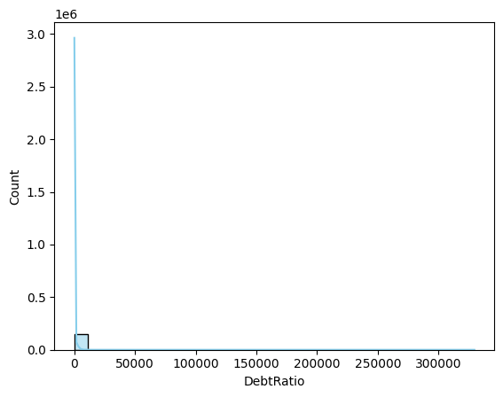

```python
sns.histplot(loans['DebtRatio'],bins=30,kde=True,color='skyblue')
```

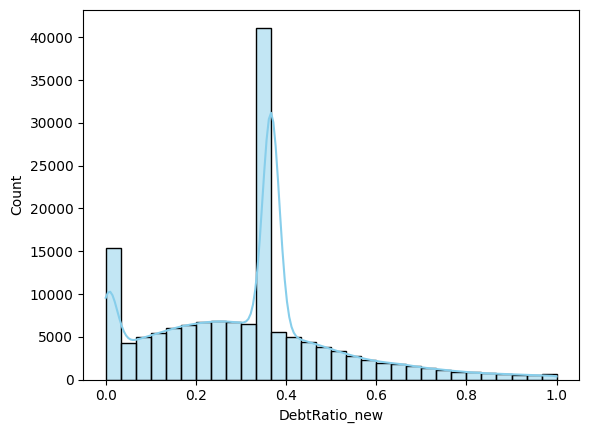

```python
sns.histplot(loans['DebtRatio_new'],bins=30,kde=True,color='skyblue')
```

# Cleaning of Discrete Variables

## Age

- greater than 80 are considered as outliers
- impute with median

```python
# impute with median
loans['age_new'] = loans['age']
loans.loc[loans['age'] > 80, 'age_new'] = loans['age'].median()
```

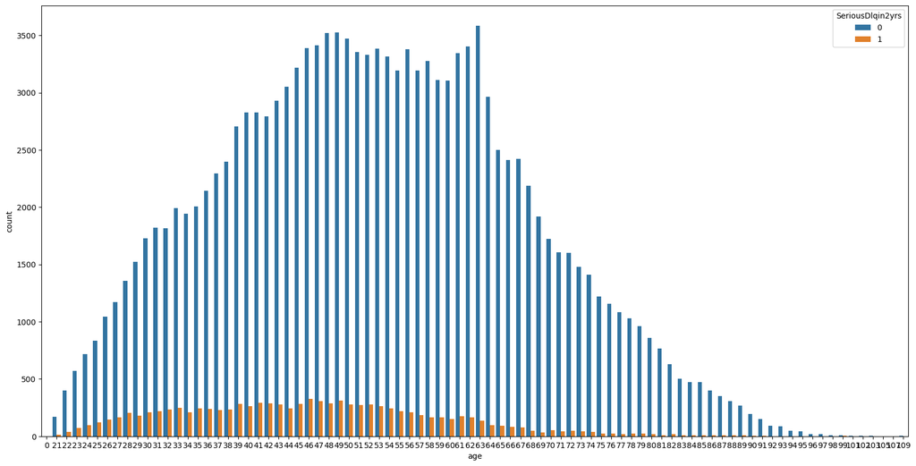

```python
plt.figure(figsize=(20,10))# this doesnt work
sns.countplot(loans, x="age",  hue="SeriousDlqin2yrs")#,multiple="stack")#y="body_mass_g",
plt.show()
```

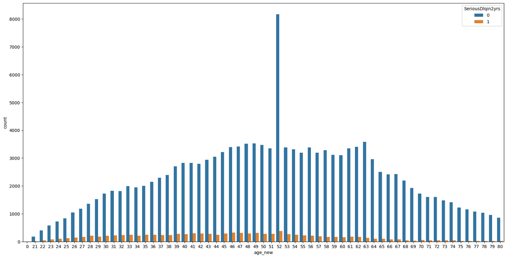

```python
plt.figure(figsize=(20,10))# this doesnt work
sns.countplot(loans, x="age_new",  hue="SeriousDlqin2yrs")#,multiple="stack")#y="body_mass_g",
plt.show()
```

- how many customers are there with age = 0 ?

```python
len(loans.loc[loans['age'] == 0])
```

```
1
```

```python
loans.loc[loans['age'] < 20, 'age_new'] = loans['age'].median()
```

```python
len(loans.loc[loans['age_new'] > 80])
```

```
0
```

## 1 month delay

```python
loans['NumberOfTime30-59DaysPastDueNotWorse'].value_counts()
```

| NumberOfTime30-59DaysPastDueNotWorse | count |
| --- | --- |
| 0 | 126018 |
| 1 | 16033 |
| 2 | 4598 |
| 3 | 1754 |
| 4 | 747 |
| 5 | 342 |
| 98 | 264 |
| 6 | 140 |
| 7 | 54 |
| 8 | 25 |
| 9 | 12 |
| 96 | 5 |
| 10 | 4 |
| 12 | 2 |
| 13 | 1 |
| 11 | 1 |

**dtype:** int64

```python
cross_tab_1_month_delay = pd.crosstab(loans['NumberOfTime30-59DaysPastDueNotWorse'],loans['SeriousDlqin2yrs'])
cross_tab_1_month_delay
```

| SeriousDlqin2yrs NumberOfTime30-59DaysPastDueNotWorse | 0 | 1 |
| --- | --- | --- |
| 0 | 120977 | 5041 |
| 1 | 13624 | 2409 |
| 2 | 3379 | 1219 |
| 3 | 1136 | 618 |
| 4 | 429 | 318 |
| 5 | 188 | 154 |
| 6 | 66 | 74 |
| 7 | 26 | 28 |
| 8 | 17 | 8 |
| 9 | 8 | 4 |
| 10 | 1 | 3 |
| 11 | 0 | 1 |
| 12 | 1 | 1 |
| 13 | 0 | 1 |
| 96 | 1 | 4 |
| 98 | 121 | 143 |

- find what percentage of customers are not seriously delinquent and seriously delinquent for each unique value.

```python
cross_tab_1_month_delay_percent = cross_tab_1_month_delay.apply(lambda x: x / x.sum() * 100, axis=1)
round(cross_tab_1_month_delay_percent,2)
```

| SeriousDlqin2yrs NumberOfTime30-59DaysPastDueNotWorse | 0 | 1 |
| --- | --- | --- |
| 0 | 96.00 | 4.00 |
| 1 | 84.97 | 15.03 |
| 2 | 73.49 | 26.51 |
| 3 | 64.77 | 35.23 |
| 4 | 57.43 | 42.57 |
| 5 | 54.97 | 45.03 |
| 6 | 47.14 | 52.86 |
| 7 | 48.15 | 51.85 |
| 8 | 68.00 | 32.00 |
| 9 | 66.67 | 33.33 |
| 10 | 25.00 | 75.00 |
| 11 | 0.00 | 100.00 |
| 12 | 50.00 | 50.00 |
| 13 | 0.00 | 100.00 |
| 96 | 20.00 | 80.00 |
| 98 | 45.83 | 54.17 |

- impute any value greater than 13 with 6

```python
loans['new_30_59_dpd_new'] = loans['NumberOfTime30-59DaysPastDueNotWorse']
loans.loc[loans['NumberOfTime30-59DaysPastDueNotWorse'] > 13, 'new_30_59_dpd_new'] = 6
loans['new_30_59_dpd_new'].value_counts()
```

| new_30_59_dpd_new | count |
| --- | --- |
| 0 | 126018 |
| 1 | 16033 |
| 2 | 4598 |
| 3 | 1754 |
| 4 | 747 |
| 6 | 409 |
| 5 | 342 |
| 7 | 54 |
| 8 | 25 |
| 9 | 12 |
| 10 | 4 |
| 12 | 2 |
| 13 | 1 |
| 11 | 1 |

**dtype:** int64

## number of open credit lines

```python
loans['NumberOfOpenCreditLinesAndLoans'].nunique()
```

```
58
```

```python
loans['NumberOfOpenCreditLinesAndLoans'].value_counts(sort=True)
```

| NumberOfOpenCreditLinesAndLoans | count |
| --- | --- |
| 6 | 13614 |
| 7 | 13245 |
| 5 | 12931 |
| 8 | 12562 |
| 4 | 11609 |
| 9 | 11355 |
| 10 | 9624 |
| 3 | 9058 |
| 11 | 8321 |
| 12 | 7005 |
| 2 | 6666 |
| 13 | 5667 |
| 14 | 4546 |
| 1 | 4438 |
| 15 | 3645 |
| 16 | 3000 |
| 17 | 2370 |
| 0 | 1888 |
| 18 | 1874 |
| 19 | 1433 |
| 20 | 1169 |
| 21 | 864 |
| 22 | 685 |
| 23 | 533 |
| 24 | 422 |
| 25 | 337 |
| 26 | 239 |
| 27 | 194 |
| 28 | 150 |
| 29 | 114 |
| 30 | 88 |
| 31 | 74 |
| 32 | 52 |
| 33 | 47 |
| 34 | 35 |
| 35 | 27 |
| 36 | 18 |
| 38 | 13 |
| 40 | 10 |
| 39 | 9 |
| 43 | 8 |
| 42 | 8 |
| 45 | 8 |
| 37 | 7 |
| 48 | 6 |
| 54 | 4 |
| 49 | 4 |
| 41 | 4 |
| 46 | 3 |
| 52 | 3 |
| 47 | 2 |
| 51 | 2 |
| 57 | 2 |
| 56 | 2 |
| 44 | 2 |
| 50 | 2 |
| 58 | 1 |
| 53 | 1 |

**dtype:** int64

```python
loans['Open_Credit_lines_new'] = loans['NumberOfOpenCreditLinesAndLoans']
loans.loc[loans['NumberOfOpenCreditLinesAndLoans'] > 20, 'Open_Credit_lines_new'] = loans['NumberOfOpenCreditLinesAndLoans'].median()
loans['Open_Credit_lines_new'].value_counts()
```

| Open_Credit_lines_new | count |
| --- | --- |
| 8 | 16542 |
| 6 | 13614 |
| 7 | 13245 |
| 5 | 12931 |
| 4 | 11609 |
| 9 | 11355 |
| 10 | 9624 |
| 3 | 9058 |
| 11 | 8321 |
| 12 | 7005 |
| 2 | 6666 |
| 13 | 5667 |
| 14 | 4546 |
| 1 | 4438 |
| 15 | 3645 |
| 16 | 3000 |
| 17 | 2370 |
| 0 | 1888 |
| 18 | 1874 |
| 19 | 1433 |
| 20 | 1169 |

**dtype:** int64

## three months delay

```python
cross_tab_90 = pd.crosstab(loans['NumberOfTimes90DaysLate'],loans['SeriousDlqin2yrs'])
cross_tab_90
```

| SeriousDlqin2yrs NumberOfTimes90DaysLate | 0 | 1 |
| --- | --- | --- |
| 0 | 135108 | 6554 |
| 1 | 3478 | 1765 |
| 2 | 779 | 776 |
| 3 | 282 | 385 |
| 4 | 96 | 195 |
| 5 | 48 | 83 |
| 6 | 32 | 48 |
| 7 | 7 | 31 |
| 8 | 6 | 15 |
| 9 | 5 | 14 |
| 10 | 3 | 5 |
| 11 | 2 | 3 |
| 12 | 1 | 1 |
| 13 | 2 | 2 |
| 14 | 1 | 1 |
| 15 | 2 | 0 |
| 17 | 0 | 1 |
| 96 | 1 | 4 |
| 98 | 121 | 143 |

```python
cross_tab_90_percent = cross_tab_90.apply(lambda x: x / x.sum() * 100, axis=1)
round(cross_tab_90_percent,2)
```

| SeriousDlqin2yrs NumberOfTimes90DaysLate | 0 | 1 |
| --- | --- | --- |
| 0 | 95.37 | 4.63 |
| 1 | 66.34 | 33.66 |
| 2 | 50.10 | 49.90 |
| 3 | 42.28 | 57.72 |
| 4 | 32.99 | 67.01 |
| 5 | 36.64 | 63.36 |
| 6 | 40.00 | 60.00 |
| 7 | 18.42 | 81.58 |
| 8 | 28.57 | 71.43 |
| 9 | 26.32 | 73.68 |
| 10 | 37.50 | 62.50 |
| 11 | 40.00 | 60.00 |
| 12 | 50.00 | 50.00 |
| 13 | 50.00 | 50.00 |
| 14 | 50.00 | 50.00 |
| 15 | 100.00 | 0.00 |
| 17 | 0.00 | 100.00 |
| 96 | 20.00 | 80.00 |
| 98 | 45.83 | 54.17 |

- impute with 3

```python
loans['num_90_dpd_new'] = loans['NumberOfTimes90DaysLate']
loans.loc[loans['NumberOfTimes90DaysLate'] > 12, 'num_90_dpd_new'] = 3
loans['num_90_dpd_new'].value_counts()
```

| num_90_dpd_new | count |
| --- | --- |
| 0 | 141662 |
| 1 | 5243 |
| 2 | 1555 |
| 3 | 945 |
| 4 | 291 |
| 5 | 131 |
| 6 | 80 |
| 7 | 38 |
| 8 | 21 |
| 9 | 19 |
| 10 | 8 |
| 11 | 5 |
| 12 | 2 |

**dtype:** int64

- Cross tab is done by comparing one numerical column with a categorical variable( a column which has categories in it).

## number of reale state loans

```python
loans['NumberRealEstateLoansOrLines'].quantile([0.9,0.95,0.99,0.995,1])
```

|  | NumberRealEstateLoansOrLines |
| --- | --- |
| 0.900 | 2.0 |
| 0.950 | 3.0 |
| 0.990 | 4.0 |
| 0.995 | 6.0 |
| 1.000 | 54.0 |

**dtype:** float64

```python
loans['Real_estate_loans_new'] = loans['NumberRealEstateLoansOrLines']
loans.loc[loans['NumberRealEstateLoansOrLines']>4 , 'Real_estate_loans_new'] = loans['NumberRealEstateLoansOrLines'].median()
loans['Real_estate_loans_new'].quantile([0.9,0.95,0.99,0.995,1])
```

|  | Real_estate_loans_new |
| --- | --- |
| 0.900 | 2.0 |
| 0.950 | 3.0 |
| 0.990 | 4.0 |
| 0.995 | 4.0 |
| 1.000 | 4.0 |

**dtype:** float64

## two month delay

```python
loans['NumberOfTime60-89DaysPastDueNotWorse'].value_counts()
```

| NumberOfTime60-89DaysPastDueNotWorse | count |
| --- | --- |
| 0 | 142396 |
| 1 | 5731 |
| 2 | 1118 |
| 3 | 318 |
| 98 | 264 |
| 4 | 105 |
| 5 | 34 |
| 6 | 16 |
| 7 | 9 |
| 96 | 5 |
| 8 | 2 |
| 11 | 1 |
| 9 | 1 |

**dtype:** int64

```python
cross_tab_60 = pd.crosstab(loans['NumberOfTime60-89DaysPastDueNotWorse'],loans['SeriousDlqin2yrs'])
cross_tab_60
```

| SeriousDlqin2yrs NumberOfTime60-89DaysPastDueNotWorse | 0 | 1 |
| --- | --- | --- |
| 0 | 135140 | 7256 |
| 1 | 3954 | 1777 |
| 2 | 557 | 561 |
| 3 | 138 | 180 |
| 4 | 40 | 65 |
| 5 | 13 | 21 |
| 6 | 4 | 12 |
| 7 | 4 | 5 |
| 8 | 1 | 1 |
| 9 | 1 | 0 |
| 11 | 0 | 1 |
| 96 | 1 | 4 |
| 98 | 121 | 143 |

```python
cross_tab_60_percent = cross_tab_60.apply(lambda x: x / x.sum() * 100, axis=1)
round(cross_tab_60_percent,2)
```

| SeriousDlqin2yrs NumberOfTime60-89DaysPastDueNotWorse | 0 | 1 |
| --- | --- | --- |
| 0 | 94.90 | 5.10 |
| 1 | 68.99 | 31.01 |
| 2 | 49.82 | 50.18 |
| 3 | 43.40 | 56.60 |
| 4 | 38.10 | 61.90 |
| 5 | 38.24 | 61.76 |
| 6 | 25.00 | 75.00 |
| 7 | 44.44 | 55.56 |
| 8 | 50.00 | 50.00 |
| 9 | 100.00 | 0.00 |
| 11 | 0.00 | 100.00 |
| 96 | 20.00 | 80.00 |
| 98 | 45.83 | 54.17 |

```python
loans['num_60_dpd_new'] = loans['NumberOfTime60-89DaysPastDueNotWorse']
loans.loc[loans['NumberOfTime60-89DaysPastDueNotWorse'] > 12, 'num_60_dpd_new'] = 3
loans['num_60_dpd_new'].value_counts()
```

| num_60_dpd_new | count |
| --- | --- |
| 0 | 142396 |
| 1 | 5731 |
| 2 | 1118 |
| 3 | 587 |
| 4 | 105 |
| 5 | 34 |
| 6 | 16 |
| 7 | 9 |
| 8 | 2 |
| 11 | 1 |
| 9 | 1 |

**dtype:** int64

## number of dependents

```python
loans['NumberOfDependents'].value_counts()
```

| NumberOfDependents | count |
| --- | --- |
| 0 | 86902 |
| 1 | 26316 |
| 2 | 19522 |
| 3 | 9483 |
| 4 | 2862 |
| 5 | 746 |
| 6 | 158 |
| 7 | 51 |
| 8 | 24 |
| 10 | 5 |
| 9 | 5 |
| 20 | 1 |
| 13 | 1 |

**dtype:** Int64

- impute with median

```python
loans['NumberOfDependents_new'] = loans['NumberOfDependents']
loans.loc[loans['NumberOfDependents'] > 10, 'NumberOfDependents_new'] = loans['NumberOfDependents'].median()
loans['NumberOfDependents_new'].value_counts()
```

| NumberOfDependents_new | count |
| --- | --- |
| 0 | 86904 |
| 1 | 26316 |
| 2 | 19522 |
| 3 | 9483 |
| 4 | 2862 |
| 5 | 746 |
| 6 | 158 |
| 7 | 51 |
| 8 | 24 |
| 10 | 5 |
| 9 | 5 |

**dtype:** Int64

- deal with null values

```python
loans.loc[loans['NumberOfDependents'].isnull(), 'NumberOfDependents_new'] = loans['NumberOfDependents'].median()
```

- data cleaning is done

# cleaned data frame

- we have both old and new columns. which columns should be used to build the model ?
- if old columns are not modified, use them
- if old columns are modified, use the new ones that are created for old columns.

## final cleaned data set

```python
loans.columns
```

```
Index(['Sr_No', 'SeriousDlqin2yrs', 'monthly_utilization', 'age',
       'NumberOfTime30-59DaysPastDueNotWorse', 'DebtRatio', 'MonthlyIncome',
       'NumberOfOpenCreditLinesAndLoans', 'NumberOfTimes90DaysLate',
       'NumberRealEstateLoansOrLines', 'NumberOfTime60-89DaysPastDueNotWorse',
       'NumberOfDependents', 'cred_util_new', 'MonthlyIncome_ind',
       'MonthlyIncome_new', 'DebtRatio_ind', 'DebtRatio_new', 'age_new',
       'new_30_59_dpd_new', 'Open_Credit_lines_new', 'num_90_dpd_new',
       'Real_estate_loans_new', 'num_60_dpd_new', 'NumberOfDependents_new'],
      dtype='object')
```

```python
loans_clean = loans.drop(['Sr_No', 'monthly_utilization', 'age',
       'NumberOfTime30-59DaysPastDueNotWorse', 'DebtRatio', 'MonthlyIncome',
       'NumberOfOpenCreditLinesAndLoans', 'NumberOfTimes90DaysLate',
       'NumberRealEstateLoansOrLines', 'NumberOfTime60-89DaysPastDueNotWorse',
       'NumberOfDependents'],axis=1).copy()
loans_clean.columns
```

```
Index(['SeriousDlqin2yrs', 'cred_util_new', 'MonthlyIncome_ind',
       'MonthlyIncome_new', 'DebtRatio_ind', 'DebtRatio_new', 'age_new',
       'new_30_59_dpd_new', 'Open_Credit_lines_new', 'num_90_dpd_new',
       'Real_estate_loans_new', 'num_60_dpd_new', 'NumberOfDependents_new'],
      dtype='object')
```

# Model Building and Validation

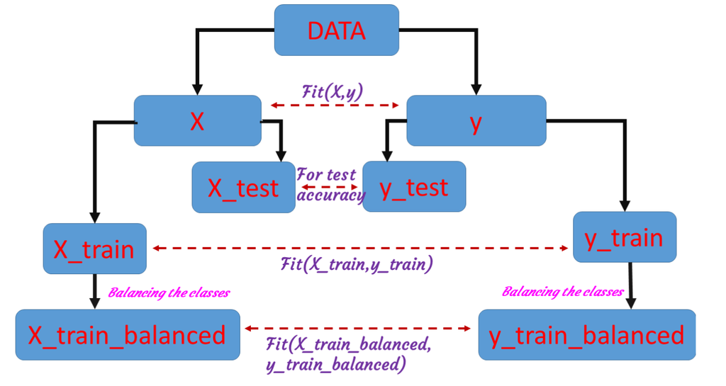

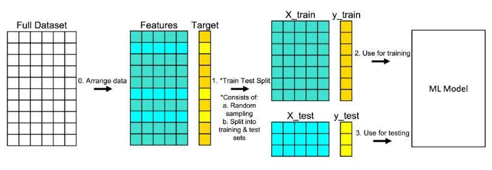

```python
# loans_clean=pd.read_csv("https://raw.githubusercontent.com/venkatareddykonasani/Datasets/master/Credit_Risk_Cleaned/Cleaned_cs_training.csv")
```

```python
loans_clean.info()
```

```
<class 'pandas.core.frame.DataFrame'>
RangeIndex: 150000 entries, 0 to 149999
Data columns (total 13 columns):
 #   Column                  Non-Null Count   Dtype
---  ------                  --------------   -----
 0   SeriousDlqin2yrs        150000 non-null  int64
 1   cred_util_new           150000 non-null  float64
 2   MonthlyIncome_ind       150000 non-null  int64
 3   MonthlyIncome_new       150000 non-null  float64
 4   DebtRatio_ind           150000 non-null  int64
 5   DebtRatio_new           150000 non-null  float64
 6   age_new                 150000 non-null  int64
 7   new_30_59_dpd_new       150000 non-null  int64
 8   Open_Credit_lines_new   150000 non-null  int64
 9   num_90_dpd_new          150000 non-null  int64
 10  Real_estate_loans_new   150000 non-null  int64
 11  num_60_dpd_new          150000 non-null  int64
 12  NumberOfDependents_new  150000 non-null  Int64
dtypes: Int64(1), float64(3), int64(9)
memory usage: 15.0 MB
```

## Model-1: Logistic Regression

```python
loans_clean['NumberOfDependents_new'] = loans_clean['NumberOfDependents_new'].astype('int64')
```

### **Split features and target variable**

```python
X = loans_clean.drop(['SeriousDlqin2yrs'],axis=1) # features/independent variables
y = loans_clean['SeriousDlqin2yrs'] # target variableb
```

1. **Feature Selection (`X`)**

   ```
   X = loans_clean.drop(['SeriousDlqin2yrs'], axis=1)
   ```

   - `drop(['SeriousDlqin2yrs'], axis=1)`: Removes the column **"SeriousDlqin2yrs"** from the DataFrame.
   - `axis=1`: Specifies that the operation is applied on **columns**.
   - The resulting `X` contains all the independent variables (features) used for prediction.
2. **Target Variable (`y`)**

   ```
   y = loans_clean['SeriousDlqin2yrs']
   ```

   - Selects the `"SeriousDlqin2yrs"` column as the dependent (target) variable.
   - `y` represents the output the model will try to predict (whether a loan defaults or not).
- **Purpose:**
- This step **separates features and target** for machine learning.
- `X` → Independent variables (predictors).
- `y` → Dependent variable (label/class to be predicted).

### build logistic regression model

```python
from sklearn.linear_model import LogisticRegression
from sklearn.model_selection import train_test_split

logistic = LogisticRegression()
logistic.fit(X,y)
```

```
LogisticRegression()
```

1. **Importing Logistic Regression Model**

   ```
   from sklearn.linear_model import LogisticRegression
   ```

   - Imports the **LogisticRegression** class from scikit-learn’s `linear_model` module.
   - This model is commonly used for **binary classification problems** (e.g., predicting default vs. non-default).
2. **Importing Train-Test Split Utility**

   ```
   from sklearn.model_selection import train_test_split
   ```

   - Imports the `train_test_split` function to split the dataset into **training** and **testing** sets.
   - Helps evaluate the model’s performance on unseen data.
3. **Creating the Logistic Regression Model**

   ```
   logistic = LogisticRegression()
   ```

   - Initializes an instance of the **LogisticRegression** model with default parameters.
   - `logistic` is now a machine learning model object ready to be trained.
4. **Fitting the Model**

   ```
   logistic.fit(X, y)
   ```

   - Trains (fits) the logistic regression model using the feature set `X` and target variable `y`.
   - The model learns the relationship between predictors (`X`) and the outcome (`y`).

Purpose:

- To build and train a **logistic regression classifier** that can predict the target variable (`SeriousDlqin2yrs`) based on the input features (`X`).
- After training, this model can be used for **predictions** on new loan data.

```python
#check intercept and coefficients
print("Intercept =", logistic.intercept_)
print("Coefficients = ", logistic.coef_)
```

```
Intercept = [-0.28557329]
Coefficients =  [[ 3.82922820e-01 -1.99002489e-01 -2.54135523e-05 -2.53999106e-01
   4.06225579e-02 -5.10680360e-02  5.44837215e-01 -1.90019050e-03
   8.09759298e-01  5.39144404e-02  4.94204367e-01 -8.45515211e-02]]
```

### **calculate accuracy of the model**

```python
import numpy as np
from sklearn.metrics import confusion_matrix
```

1. **Importing NumPy**

   ```
   import numpy as np
   ```

   - Imports the **NumPy** library, which is widely used for **numerical operations** in Python.
   - Provides support for arrays, mathematical functions, and matrix operations, which are often needed in machine learning workflows.
2. **Importing Confusion Matrix Function**

   ```
   from sklearn.metrics import confusion_matrix
   ```

   - Imports the `confusion_matrix` function from scikit-learn’s `metrics` module.
   - Used to evaluate a **classification model’s performance** by comparing predicted labels with actual labels.
   - Produces a matrix showing **True Positives (TP), False Positives (FP), True Negatives (TN), and False Negatives (FN)**.

Purpose:

- `NumPy` → Provides efficient numerical computations that support ML operations.
- `confusion_matrix` → Helps measure how well a classification model performs by showing correct vs. incorrect predictions.
- Make predictions on X using the model that is built

```python
predict = logistic.predict(X)
cm = confusion_matrix(y,predict)
print("Confusion matrix \n",cm)
```

```
Confusion matrix
 [[138892   1082]
 [  8430   1596]]
```

1. **Making Predictions**

   ```
   predict = logistic.predict(X)
   ```

   - Uses the trained **logistic regression model** (`logistic`) to predict outcomes for the feature set `X`.
   - The result `predict` is an array of predicted class labels (e.g., 0 = no default, 1 = default).
2. **Creating Confusion Matrix**

   ```
   cm = confusion_matrix(y, predict)
   ```

   - Compares the **actual labels** (`y`) with the **predicted labels** (`predict`).
   - Returns a confusion matrix with counts of:
     - **True Negatives (TN)**
     - **False Positives (FP)**
     - **False Negatives (FN)**
     - **True Positives (TP)**
3. **Displaying Confusion Matrix**

   ```
   print("Confusion matrix \n", cm)
   ```

   - Prints the confusion matrix in a readable format.
   - Helps analyze the classification performance of the model.

Purpose:

- To evaluate the **accuracy and errors** of the logistic regression model.
- The confusion matrix provides deeper insight than accuracy alone by showing **where the model predicts correctly and where it makes mistakes**.

🔹 Positive vs Negative in a Confusion Matrix

| Class Type | Label | Meaning | Example |
| --- | --- | --- | --- |
| Positive | 1 | The class you want to detect | "Has disease", "Will default", "Fraudulent transaction" |
| Negative | 0 | The other class | "No disease", "Will not default", "Legitimate transaction" |

🔹 Examples

| Scenario | Positive (1) | Negative (0) |
| --- | --- | --- |
| Medical Test | Patient has the disease | Patient does not have the disease |
| Credit Risk Model | Customer will default | Customer will not default |

```python
# calculate accuracy
total = sum(sum(cm))
accuracy = (cm[0,0] + cm[1,1])/ total
print("Accuracy of this model is ", accuracy)
```

```
Accuracy of this model is  0.9365866666666667
```

1. **Calculating Total Predictions**

   ```
   total = sum(sum(cm))
   ```

   - `cm` is a 2×2 confusion matrix.
   - `sum(cm)` → Sums each row of the confusion matrix.
   - `sum(sum(cm))` → Adds those row sums together to get the **total number of predictions**.
2. **Calculating Accuracy**

   ```
   accuracy = (cm[0,0] + cm[1,1]) / total
   ```

   - `cm[0,0]`: **True Negatives (TN)** → Correctly predicted negatives.
   - `cm[1,1]`: **True Positives (TP)** → Correctly predicted positives.
   - `(cm[0,0] + cm[1,1])`: Total correct predictions.
   - Dividing by `total` gives the **accuracy** (fraction of correct predictions out of all predictions).
3. **Printing Accuracy**

   ```
   print("Accuracy of this model is ", accuracy)
   ```

   - Displays the calculated accuracy score of the model.

Purpose:

- To measure the **overall performance** of the logistic regression model.
- Accuracy indicates the **percentage of correct predictions** made by the model.

### **Checking p-values**

- Impactful feature or not
- if p> 0.05 drop it.

```python
import statsmodels.api as sm

sm_model = sm.Logit(y,X)
sm_result = sm_model.fit()
print(sm_result.summary())
```

```
Optimization terminated successfully.
         Current function value: 0.202887
         Iterations 8
                           Logit Regression Results
==============================================================================
Dep. Variable:       SeriousDlqin2yrs   No. Observations:               150000
Model:                          Logit   Df Residuals:                   149988
Method:                           MLE   Df Model:                           11
Date:                Fri, 12 Sep 2025   Pseudo R-squ.:                  0.1732
Time:                        03:10:54   Log-Likelihood:                -30433.
converged:                       True   LL-Null:                       -36808.
Covariance Type:            nonrobust   LLR p-value:                     0.000
==========================================================================================
                             coef    std err          z      P>|z|      [0.025      0.975]
------------------------------------------------------------------------------------------
cred_util_new              0.8780      0.030     29.593      0.000       0.820       0.936
MonthlyIncome_ind         -0.1853      0.045     -4.084      0.000      -0.274      -0.096
MonthlyIncome_new      -3.336e-05   3.68e-06     -9.061      0.000   -4.06e-05   -2.61e-05
DebtRatio_ind             -0.4805      0.043    -11.122      0.000      -0.565      -0.396
DebtRatio_new             -0.1316      0.065     -2.018      0.044      -0.259      -0.004
age_new                   -0.0576      0.001    -79.959      0.000      -0.059      -0.056
new_30_59_dpd_new          0.4799      0.011     42.864      0.000       0.458       0.502
Open_Credit_lines_new      0.0003      0.003      0.103      0.918      -0.006       0.007
num_90_dpd_new             0.6803      0.016     41.531      0.000       0.648       0.712
Real_estate_loans_new      0.0568      0.015      3.718      0.000       0.027       0.087
num_60_dpd_new             0.5633      0.023     24.974      0.000       0.519       0.608
NumberOfDependents_new     0.0392      0.010      3.971      0.000       0.020       0.059
==========================================================================================
```

### Verify Multicollinearity

```python
# Defining user defined function for Variation Inflation Factor
def vif_cal(input_data,dependent_col):
  import statsmodels.formula.api as sm
  x_vars=input_data.drop([dependent_col], axis=1)
  xvar_names=x_vars.columns
  for i in range(0,xvar_names.shape[0]):
    y=x_vars[xvar_names[i]]
    x=x_vars[xvar_names.drop(xvar_names[i])]
    rsq=sm.ols(formula="y~x", data=x_vars).fit().rsquared
    vif=round(1/(1-rsq),2)
    print (xvar_names[i], " VIF = " , vif)
```

```
import statsmodels.formula.api as sm
```

- This imports the formula API from the statsmodels library.
- The formula API allows you to specify statistical models in a more user-friendly way (e.g., using a formula like y ~ x1 + x2),
- and the ols function (ordinary least squares) is used to fit linear regression models.
- sm is the alias for accessing the statsmodels.formula.api module.

```
def vif_cal(input_data, dependent_col):
```

```
x_vars = input_data.drop([dependent_col], axis=1)
```

- This line drops the column corresponding to the dependent variable (dependent_col) from the dataset (input_data), leaving only the independent variables (predictors).
- axis=1: Specifies that we are dropping columns, not rows.
- Result: x_vars is the DataFrame that contains only the independent variables.

```
xvar_names = x_vars.columns
```

- This stores the names of the independent variables (column names) in the x_vars DataFrame into a variable xvar_names.

```
for i in range(0, xvar_names.shape[0]):
  y = x_vars[xvar_names[i]]
  x = x_vars[xvar_names.drop(xvar_names[i])]
```

- y = x_vars[xvar_names[i]]:
  - In each iteration, y is set to the current independent variable (the one whose VIF we are calculating).
  - x_vars[xvar_names[i]] extracts the column corresponding to the i-th variable from x_vars.
- x = x_vars[xvar_names.drop(xvar_names[i])]:
- This line creates a new DataFrame x, which contains all the independent variables except for the current variable xvar_names[i].

xvar_names.drop(xvar_names[i]) removes the current variable from the list of independent variables, so x includes all other variables.

```python
vif_cal(loans_clean,'SeriousDlqin2yrs')
```

```
cred_util_new  VIF =  1.19
MonthlyIncome_ind  VIF =  3.35
MonthlyIncome_new  VIF =  1.04
DebtRatio_ind  VIF =  3.26
DebtRatio_new  VIF =  1.41
age_new  VIF =  1.15
new_30_59_dpd_new  VIF =  1.25
Open_Credit_lines_new  VIF =  1.36
num_90_dpd_new  VIF =  1.22
Real_estate_loans_new  VIF =  1.5
num_60_dpd_new  VIF =  1.28
NumberOfDependents_new  VIF =  1.11
```

- All variables have VIF < 5. So no need to drop any variable.

### Build a model without mulitcollinearity and with impactful variables

```python
X1 = loans_clean.drop(['Open_Credit_lines_new','DebtRatio_new','SeriousDlqin2yrs'],axis=1)
y1 = loans_clean['SeriousDlqin2yrs']
```

```python
logistic2 = LogisticRegression()
logistic2.fit(X1,y1)
```

```
LogisticRegression()
```

- prediction

```python
predict1 = logistic2.predict(X1)
cm2 = confusion_matrix(y1,predict1)
print("Confusion matrix \n",cm2)
```

```
Confusion matrix
 [[138862   1112]
 [  8409   1617]]
```

- calculate **accuracy**

```python
# calculate accuracy
total = sum(sum(cm2))
accuracy = (cm2[0,0] + cm2[1,1])/ total
print("Accuracy of this model is ", accuracy)
```

```
Accuracy of this model is  0.9365266666666666
```

- Compute **sensitivity** (class - 0 accuracy)
- Compute **Specificity** (class - 1 accuracy)

```python
sensitivity = cm2[0,0]/(cm2[0,0] + cm2[0,1])
specificity = cm2[1,1]/(cm2[1,0] + cm2[1,1])
print("sensitivity is", sensitivity)
print("specificity is", specificity)
```

```
sensitivity is 0.9920556674811036
specificity is 0.16128067025733095
```

1. **Calculating Sensitivity (Recall / True Positive Rate)**

   ```
   sensitivity = cm2[0,0] / (cm2[0,0] + cm2[0,1])
   ```

   ```
   specificity = cm2[1,1] / (cm2[1,0] + cm2[1,1])
   ```

Purpose:

- **Sensitivity** → Focuses on the model’s ability to detect actual positives (minimizing missed cases).
- **Specificity** → Focuses on the model’s ability to detect actual negatives (minimizing false alarms).

### predict probabilities

```python
prediction_probability = logistic2.predict_proba(X1)
prediction_probability[:,1]
```

```
array([0.12056618, 0.07959371, 0.2089276 , ..., 0.03750802, 0.06084666,
       0.02196097])
```

Explanation:

1. **Predicting Class Probabilities**

   ```
   prediction_probability = logistic2.predict_proba(X1)
   ```

   - `logistic2`: A trained Logistic Regression model.
   - `predict_proba(X1)`: Returns the **predicted probabilities** for each class for every sample in `X1`.
   - Output is a 2D array:
     - Column `0`: Probability of class **0** (negative class).
     - Column `1`: Probability of class **1** (positive class).
   - Example: `[0.8, 0.2]` means the model predicts 80% chance of class 0 and 20% chance of class 1.

Purpose:

- Instead of just predicting the final class label, this gives the **confidence level** of the model in its predictions.
- Useful for:
  - **Threshold tuning** (changing the cutoff from 0.5 to another value).
  - **ROC/AUC analysis**.
  - Cases where probability information is more informative than just a binary decision.

### threshold = **0.5**

```python
# threshold = 0.5
threshold = 0.5
predict = [0 if x < threshold else 1 for x in list(prediction_probability[:,1])]
print(predict[0:5])
```

```
[0, 0, 0, 0, 0]
```

Explanation:

1. **Setting the Threshold**

   ```
   threshold = 0.5
   ```

   - Defines the **decision boundary** for classification.
   - If predicted probability ≥ `0.5` → classify as **1 (positive class)**.
   - If predicted probability < `0.5` → classify as **0 (negative class)**.
2. **Applying the Threshold**

   ```
   predict = [0 if x < threshold else 1 for x in list(prediction_probability[:,1])]
   ```

   - `prediction_probability[:,1]`: Extracts the probability of class **1 (positive class)** from the prediction array.
   - `list(...)`: Converts it into a Python list for iteration.
   - List comprehension:
     - If probability `< threshold`, assign **0**.
     - If probability `≥ threshold`, assign **1**.
   - The result is a list `predict` containing **final class predictions** based on the chosen threshold.

Purpose:

- Allows **custom thresholding** instead of relying on the default `0.5`.
- Helps improve model performance for specific needs (e.g., higher sensitivity or higher specificity).

```python
cm = confusion_matrix(y1,predict)
print(cm)

# calculate accuracy
total = sum(sum(cm))
accuracy = (cm[0,0] + cm[1,1])/ total
print("Accuracy of this model is ", accuracy)

sensitivity = cm[0,0]/(cm[0,0] + cm[0,1])
specificity = cm[1,1]/(cm[1,0] + cm[1,1])
print("sensitivity is", sensitivity)
print("specificity is", specificity)
```

```
[[138862   1112]
 [  8409   1617]]
Accuracy of this model is  0.9365266666666666
sensitivity is 0.9920556674811036
specificity is 0.16128067025733095
```

### threshold = **0.8**

```python
threshold = 0.8
predict = [0 if x < threshold else 1 for x in list(prediction_probability[:,1])]
print(predict[0:5])
```

```
[0, 0, 0, 0, 0]
```

```python
cm = confusion_matrix(y,predict)
print(cm)

# calculate accuracy
total = sum(sum(cm))
accuracy = (cm[0,0] + cm[1,1])/ total
print("Accuracy of this model is ", accuracy)

sensitivity = cm[0,0]/(cm[0,0] + cm[0,1])
specificity = cm[1,1]/(cm[1,0] + cm[1,1])
print("sensitivity is", sensitivity)
print("specificity is", specificity)
```

```
[[139559    415]
 [  9270    756]]
Accuracy of this model is  0.9354333333333333
sensitivity is 0.9970351636732536
specificity is 0.07540394973070018
```

As threshold increases from 0.5 to 0.8, the sensitivity (class 0 accuracy) increases and specificity(class 1 accuracy) decreases.

- class 1 accuracy is very important. However it is very low..

### threshold = **0.2**

```python
threshold = 0.2
predict = [0 if x < threshold else 1 for x in list(prediction_probability[:,1])]
print(predict[0:5])
```

```
[0, 0, 1, 0, 0]
```

```python
cm = confusion_matrix(y,predict)
print(cm)

# calculate accuracy
total = sum(sum(cm))
accuracy = (cm[0,0] + cm[1,1])/ total
print("Accuracy of this model is ", accuracy)

sensitivity = cm[0,0]/(cm[0,0] + cm[0,1])
specificity = cm[1,1]/(cm[1,0] + cm[1,1])
print("sensitivity is", sensitivity)
print("specificity is", specificity)
```

```
[[135340   4634]
 [  6433   3593]]
Accuracy of this model is  0.92622
sensitivity is 0.9668938517153186
specificity is 0.35836824256931976
```

As threshold is decreases from 0.5 to 0.2, the sensitivity decreases(class 0 accuracy) and the specificity increases(class 1 accuracy).

## Model-2: decision tree model

```python
X = loans_clean.drop(['SeriousDlqin2yrs'],axis=1)
y = loans_clean['SeriousDlqin2yrs']
```

### Build decision tree classifier

```python
from sklearn.tree import DecisionTreeClassifier
# Building a Decision Tree model
Dtree= DecisionTreeClassifier(max_depth = 3)   # check for maxdept =2,1
Dtree.fit(X,y)
```

```
DecisionTreeClassifier(max_depth=3)
```

Explanation:

1. **Importing Decision Tree Classifier**

   ```
   from sklearn.tree import DecisionTreeClassifier
   ```

   - Imports the `DecisionTreeClassifier` class from scikit-learn.
   - Decision Trees are used for **classification** tasks by learning **if-else rules** from features.
2. **Creating the Decision Tree Model**

   ```
   Dtree = DecisionTreeClassifier(max_depth=3)
   ```

   - Initializes a Decision Tree classifier.
   - `max_depth=3`: Limits the depth of the tree to **3 levels** to prevent overfitting.
   - Comment suggests experimenting with `max_depth=1` or `2` to see how tree depth affects performance.
3. **Fitting the Model**

   ```
   Dtree.fit(X, y)
   ```

   - Trains the Decision Tree on the features `X` and target `y`.
   - The model learns **splitting rules** that classify the target variable based on feature values.

Purpose:

- To build a **Decision Tree classifier** that can predict the target variable (`SeriousDlqin2yrs`) using the input features (`X`).
- `max_depth` helps control **model complexity** and prevents overfitting to the training data.

```
|--- num_90_dpd_new <= 0.50
|   |--- new_30_59_dpd_new <= 0.50
|   |   |--- cred_util_new <= 0.50
|   |   |   |--- class: 0
|   |   |--- cred_util_new >  0.50
|   |   |   |--- class: 0
|   |--- new_30_59_dpd_new >  0.50
|   |   |--- num_60_dpd_new <= 0.50
|   |   |   |--- class: 0
|   |   |--- num_60_dpd_new >  0.50
|   |   |   |--- class: 0
|--- num_90_dpd_new >  0.50
|   |--- num_90_dpd_new <= 1.50
|   |   |--- num_60_dpd_new <= 0.50
|   |   |   |--- class: 0
|   |   |--- num_60_dpd_new >  0.50
|   |   |   |--- class: 0
|   |--- num_90_dpd_new >  1.50
|   |   |--- new_30_59_dpd_new <= 0.50
|   |   |   |--- class: 0
|   |   |--- new_30_59_dpd_new >  0.50
|   |   |   |--- class: 1
```

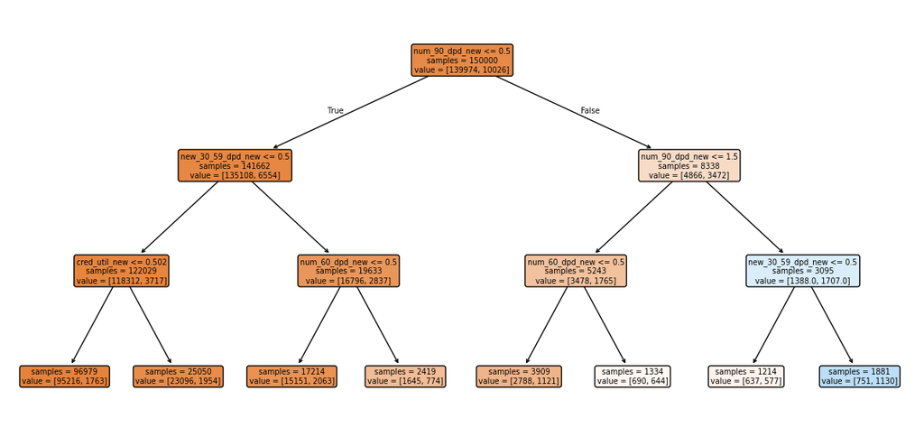

```python
# Plotting the tree
from sklearn.tree import plot_tree, export_text
plt.figure(figsize = (15,7))
plot_tree(Dtree , filled = True , rounded = True , impurity = False  , feature_names = list(X.columns))
print(export_text(Dtree , feature_names = list(X.columns)))
plt.show()
```

Explanation:

1. **Importing Tree Visualization Tools**

   ```
   from sklearn.tree import plot_tree, export_text
   ```

   - `plot_tree`: Plots a visual representation of the Decision Tree.
   - `export_text`: Returns a **text-based representation** of the tree with rules and splits.
2. **Setting Figure Size**

   ```
   plt.figure(figsize=(15,7))
   ```

   - Creates a figure of size **15×7 inches** for the tree plot.
   - Ensures the tree is large enough to view all nodes clearly.
3. **Plotting the Decision Tree**

   ```
   plot_tree(Dtree, filled=True, rounded=True, impurity=False, feature_names=list(X.columns))
   ```

   - `filled=True`: Colors the nodes based on class prediction.
   - `rounded=True`: Renders nodes with rounded corners for readability.
   - `impurity=False`: Hides the Gini impurity values in the nodes.
   - `feature_names=list(X.columns)`: Displays **feature names** in the splits instead of generic labels.
4. **Printing Text Representation**

   ```
   print(export_text(Dtree, feature_names=list(X.columns)))
   ```

   - Prints the tree rules as **text**, showing how the model splits features to make predictions.
   - Useful for **quick inspection** without plotting.
5. **Displaying the Plot**

   ```
   plt.show()
   ```

   - Renders the tree plot on the screen.

Purpose:

- To **visualize the structure** of the trained Decision Tree model.
- Helps understand **how the model makes decisions** and which features are most important.
- Text representation provides a **readable summary** of splitting rules for each node.

### find its accuracy

```python
# Finding the accuracy of the model
predict = Dtree.predict(X)

cm = confusion_matrix(y,predict)
print(cm)

total = sum(sum(cm))
accuracy = (cm[0,0] + cm[1,1]) / total
print("Accuracy of the decision tree model = " , accuracy)
```

```
[[139223    751]
 [  8896   1130]]
Accuracy of the decision tree model =  0.9356866666666667
```

### Check for overfitting

When really large tree is build , the model is very likely to be overfitted. Overfitted model means that the train accuracy is very large whereas the test accuracy is considerably very low. If the train and test accuracy differ by more than 5 points then the model is considered as overfitted model.

```python
X = loans_clean.drop(['SeriousDlqin2yrs'],axis = 1)
y = loans_clean['SeriousDlqin2yrs']

# Creating train and test data
from sklearn.model_selection import train_test_split
X_train, X_test , y_train, y_test = train_test_split(X,y, train_size = 0.8 , random_state = 22)
```

1. Splitting Data into Training and Testing Sets

```
from sklearn.model_selection import train_test_split
X_train, X_test, y_train, y_test = train_test_split(X, y, train_size=0.8, random_state=22)
```

- `train_test_split()` is a function from `sklearn.model_selection` that **splits data into training and test sets**.
- **`train_size=0.8`**:
  - **80% of the data** is used for training (`X_train`, `y_train`).
  - **20% is used for testing** (`X_test`, `y_test`).
- **`random_state=22`**:
  - Ensures that the **same random split** is generated every time you run the code.
  - If you use a different `random_state`, the split will be different.
2. Why Split the Data?
- **Training Set (`X_train`, `y_train`)**:
  - Used to **train the model** (i.e., help it learn patterns).
- **Testing Set (`X_test`, `y_test`)**:
  - Used to **evaluate the model** on unseen data to check accuracy.
3. Example of Data Splitting

If we had **10 rows** in `loans`, an **80-20 split** would look like this:

### **Training Set (80% - 8 Rows)**

| Age | Income | Debt | Target (`y_train`) |
| --- | --- | --- | --- |
| 25 | 50000 | 2000 | 0 |
| 40 | 60000 | 5000 | 1 |
| 35 | 45000 | 3000 | 0 |
| 50 | 80000 | 7000 | 1 |
| 29 | 55000 | 2500 | 0 |
| 48 | 75000 | 6500 | 1 |
| 38 | 62000 | 4000 | 0 |
| 60 | 90000 | 8000 | 1 |

### **Test Set (20% - 2 Rows)**

| Age | Income | Debt | Target (`y_test`) |
| --- | --- | --- | --- |
| 32 | 52000 | 2800 | 0 |
| 45 | 70000 | 6000 | 1 |

4. Next Steps After Splitting

Once the data is split, you can:

- **Train a machine learning model** using `X_train` and `y_train`:

  ```
  from sklearn.tree import DecisionTreeClassifier

  model = DecisionTreeClassifier(max_depth=2)
  model.fit(X_train, y_train)
  ```

- **Evaluate the model** using `X_test` and `y_test`:

  ```
  from sklearn.metrics import accuracy_score

  y_pred = model.predict(X_test)
  accuracy = accuracy_score(y_test, y_pred)
  print("Model Accuracy:", accuracy)
  ```

## **Summary of Key Concepts**

| **Step** | **Code** | **Purpose** |
| --- | --- | --- |
| **1. Split Data into Train/Test Sets** | `train_test_split(X, y, train_size=0.8, random_state=22)` | Splits data into **80% train** and **20% test**. |
| **2. Train Model** | `model.fit(X_train, y_train)` | Trains a machine learning model. |
| **3. Test Model** | `model.predict(X_test)` | Makes predictions on the test set. |

```python
# training the model
from sklearn import tree
Dtree1 = tree.DecisionTreeClassifier(max_depth = 3)
Dtree1.fit(X_train,y_train)
```

```
DecisionTreeClassifier(max_depth=3)
```

```
|--- num_90_dpd_new <= 0.50
|   |--- new_30_59_dpd_new <= 0.50
|   |   |--- cred_util_new <= 0.53
|   |   |   |--- class: 0
|   |   |--- cred_util_new >  0.53
|   |   |   |--- class: 0
|   |--- new_30_59_dpd_new >  0.50
|   |   |--- num_60_dpd_new <= 0.50
|   |   |   |--- class: 0
|   |   |--- num_60_dpd_new >  0.50
|   |   |   |--- class: 0
|--- num_90_dpd_new >  0.50
|   |--- num_90_dpd_new <= 1.50
|   |   |--- num_60_dpd_new <= 0.50
|   |   |   |--- class: 0
|   |   |--- num_60_dpd_new >  0.50
|   |   |   |--- class: 0
|   |--- num_90_dpd_new >  1.50
|   |   |--- new_30_59_dpd_new <= 0.50
|   |   |   |--- class: 0
|   |   |--- new_30_59_dpd_new >  0.50
|   |   |   |--- class: 1
```

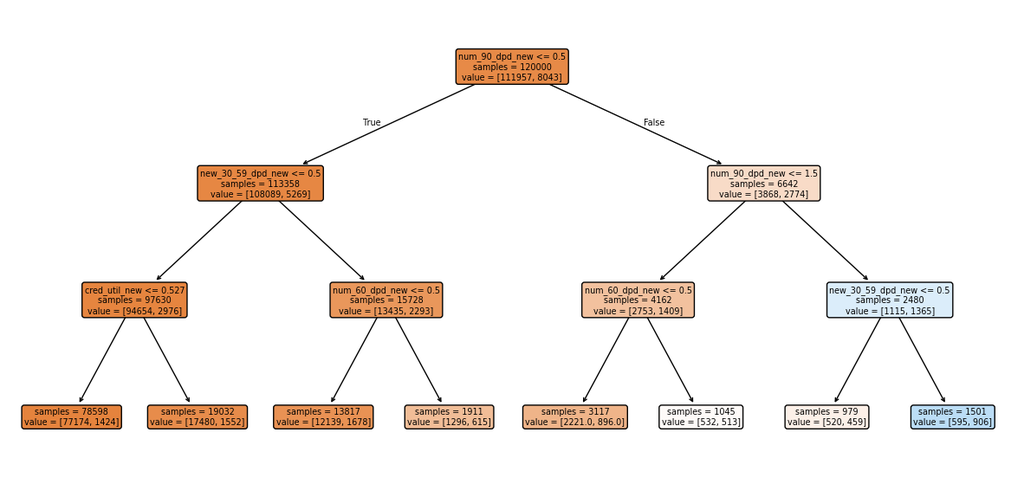

```python
# Plotting the model using train data
from sklearn.tree import plot_tree , export_text
plt.figure(figsize = (15,7))
plot_tree(Dtree1, filled = True , rounded = True , impurity = False , feature_names = list(X.columns))
print( export_text(Dtree1, feature_names =list(X.columns)))
```

### Find train accuracy

```python
# Finding the accuracy of the model on train data
predict = Dtree1.predict(X_train)

cm = confusion_matrix(y_train,predict)
print(cm)

total = sum(sum(cm))
accuracy = (cm[0,0] + cm[1,1]) / total
print("Accuracy of the  model on train data= " , accuracy)
```

```
[[111362    595]
 [  7137    906]]
Accuracy of the  model on train data=  0.9355666666666667
```

```python
sensitivity = (cm[0,0]) / (cm[0,0]+cm[0,1])
print("Sensitivity = " , sensitivity)

specificity = (cm[1,1]) / (cm[1,0] + cm[1,1])
print("Specificty = " , specificity)
```

```
Sensitivity =  0.9946854595960949
Specificty =  0.11264453562103692
```

- Find test accuracy

```python
# Finding the accuracy of the model on test data
predict = Dtree1.predict(X_test)

cm = confusion_matrix(y_test,predict)
print(cm)

total = sum(sum(cm))
accuracy = (cm[0,0] + cm[1,1]) / total
print("Accuracy of the decision tree model on test data = " , accuracy)
```

```
[[27861   156]
 [ 1759   224]]
Accuracy of the decision tree model on test data =  0.9361666666666667
```

```python
sensitivity = (cm[0,0]) / (cm[0,0]+cm[0,1])
print("Sensitivity = " , sensitivity)

specificity = (cm[1,1]) / (cm[1,0] + cm[1,1])
print("Specificty = " , specificity)
```

```
Sensitivity =  0.9944319520291252
Specificty =  0.1129601613716591
```

Here we can observe that the train and test accuracy are close enough. Hence the model is not overfitted.

- No need to check for underfitting

## Handling Class Imablance using SMOTE technique

```python
from imblearn.over_sampling import SMOTE
smote=SMOTE(sampling_strategy=0.6, random_state=44)

X_train_smote, y_train_smote=smote.fit_resample(X_train,y_train)

import collections
print("Before SMOTE", collections.Counter(y_train))
print("After SMOTE", collections.Counter(y_train_smote))
```

```
Before SMOTE Counter({0: 111957, 1: 8043})
After SMOTE Counter({0: 111957, 1: 67174})
```

```
from imblearn.over_sampling import SMOTE
```

- This imports the SMOTE class from the imblearn library, which is a popular tool for handling imbalanced datasets.
- SMOTE is an oversampling technique that creates synthetic examples for the minority class by interpolating between existing examples.
- It is used to balance the class distribution when one class has significantly fewer instances than the other.

```
smote = SMOTE(sampling_strategy=0.6, random_state=44)
```

- sampling_strategy=0.6: This parameter specifies the desired balance between the majority and minority classes after resampling. It means that the number of synthetic samples created for the minority class will make its size 60% of the size of the majority class.
- For example, if the majority class has 1000 samples, the minority class will have 600 samples after resampling.
- random_state=44: This sets the random seed for reproducibility. Using the same random_state ensures that the synthetic samples generated by SMOTE are the same each time the code is run.

```
X_train_smote, y_train_smote = smote.fit_resample(X_train, y_train)
```

- smote.fit_resample(X_train, y_train):
  - fit_resample(): This method applies SMOTE to the training data. It creates synthetic samples for the minority class in the training set, making the class distribution more balanced.
- The function returns:
  - X_train_smote: The resampled feature matrix (with synthetic samples added).
  - y_train_smote: The resampled target vector (with synthetic samples added).

## Model-3 Logistic Regression with balanced data - SMOTE

```python
model=sm.Logit(y_train_smote,X_train_smote).fit()
print(model.summary())
```

```
Optimization terminated successfully.
         Current function value: 0.496510
         Iterations 7
                           Logit Regression Results
==============================================================================
Dep. Variable:       SeriousDlqin2yrs   No. Observations:               179131
Model:                          Logit   Df Residuals:                   179119
Method:                           MLE   Df Model:                           11
Date:                Fri, 12 Sep 2025   Pseudo R-squ.:                  0.2495
Time:                        03:11:08   Log-Likelihood:                -88940.
converged:                       True   LL-Null:                   -1.1851e+05
Covariance Type:            nonrobust   LLR p-value:                     0.000
==========================================================================================
                             coef    std err          z      P>|z|      [0.025      0.975]
------------------------------------------------------------------------------------------
cred_util_new              1.7136      0.017    100.935      0.000       1.680       1.747
MonthlyIncome_ind          1.1575      0.024     48.076      0.000       1.110       1.205
MonthlyIncome_new       1.244e-05    1.1e-06     11.299      0.000    1.03e-05    1.46e-05
DebtRatio_ind             -1.2228      0.022    -56.472      0.000      -1.265      -1.180
DebtRatio_new              1.6600      0.034     48.561      0.000       1.593       1.727
age_new                   -0.0360      0.000   -107.463      0.000      -0.037      -0.035
new_30_59_dpd_new          0.5071      0.008     62.832      0.000       0.491       0.523
Open_Credit_lines_new      0.0050      0.002      3.051      0.002       0.002       0.008
num_90_dpd_new             0.7339      0.014     52.893      0.000       0.707       0.761
Real_estate_loans_new     -0.5424      0.009    -63.524      0.000      -0.559      -0.526
num_60_dpd_new             0.4033      0.018     22.809      0.000       0.369       0.438
NumberOfDependents_new    -0.1742      0.006    -29.414      0.000      -0.186      -0.163
==========================================================================================
```

```python
#Confusion matrix and Accuracy
tran_pred=model.predict(X_train_smote)
test_pred=model.predict(X_test)

#confusion matrix
train_cm=confusion_matrix(y_train_smote,np.round(tran_pred))
test_cm=confusion_matrix(y_test,np.round(test_pred))

print("Train Confusion Matrix\n", train_cm)
print("Test Confusion Matrix\n", test_cm)
```

```
Train Confusion Matrix
 [[95729 16228]
 [26696 40478]]
Test Confusion Matrix
 [[23945  4072]
 [  807  1176]]
```

```python
#Class-0 and Class-1 Accuracy
class_0_acc=train_cm[0,0]/(train_cm[0,0]+train_cm[0,1])
class_1_acc=train_cm[1,1]/(train_cm[1,0]+train_cm[1,1])

print("Class-0 Accuracy", class_0_acc)
print("Class-1 Accuracy", class_1_acc)
```

```
Class-0 Accuracy 0.8550514929839135
Class-1 Accuracy 0.6025843332241642
```

```python
#Class-0 and Class-1 Accuracy on test data
class_0_acc=test_cm[0,0]/(test_cm[0,0]+test_cm[0,1])
class_1_acc=test_cm[1,1]/(test_cm[1,0]+test_cm[1,1])

print("Class-0 Accuracy", class_0_acc)
print("Class-1 Accuracy", class_1_acc)
```

```
Class-0 Accuracy 0.8546596709140879
Class-1 Accuracy 0.5930408472012103
```

- Specificity has increased

## Model-4: Decision Tree on Balanced Data -SMOTE

### with max depth = 2

```python
# training the model
from sklearn import tree
Dtree2 = tree.DecisionTreeClassifier(max_depth = 2)
Dtree2.fit(X_train_smote,y_train_smote)
```

```
DecisionTreeClassifier(max_depth=2)
```

```
|--- cred_util_new <= 0.15
|   |--- num_90_dpd_new <= 0.50
|   |   |--- class: 0
|   |--- num_90_dpd_new >  0.50
|   |   |--- class: 1
|--- cred_util_new >  0.15
|   |--- num_90_dpd_new <= 0.50
|   |   |--- class: 0
|   |--- num_90_dpd_new >  0.50
|   |   |--- class: 1
```

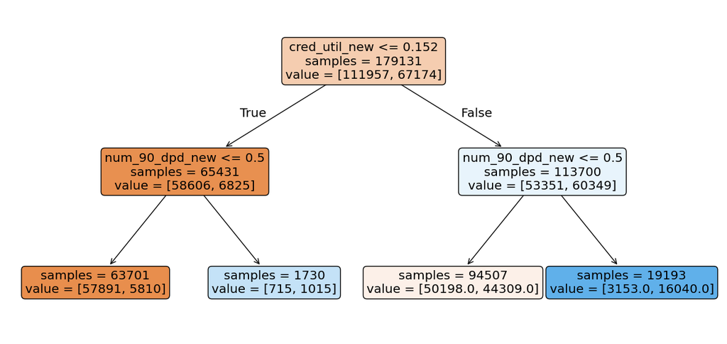

```python
# Plotting the model using train data
from sklearn.tree import plot_tree , export_text
plt.figure(figsize = (15,7))
plot_tree(Dtree2, filled = True , rounded = True , impurity = False , feature_names = list(X.columns))
print( export_text(Dtree2, feature_names =list(X.columns)))
```

```python
# Finding the accuracy of the model on train data
predict = Dtree2.predict(X_train_smote)

cm = confusion_matrix(y_train_smote,predict)
print(cm)

total = sum(sum(cm))
accuracy = (cm[0,0] + cm[1,1]) / total
print("Accuracy of the  model on train data= " , accuracy)
```

```
[[108089   3868]
 [ 50119  17055]]
Accuracy of the  model on train data=  0.6986172131010266
```

```python
sensitivity = (cm[0,0]) / (cm[0,0]+cm[0,1])
print("Sensitivity = " , sensitivity)

specificity = (cm[1,1]) / (cm[1,0] + cm[1,1])
print("Specificty = " , specificity)
```

```
Sensitivity =  0.9654510213742776
Specificty =  0.253892875219579
```

```python
# Finding the accuracy of the model on test data
predict = Dtree2.predict(X_test)

cm = confusion_matrix(y_test,predict)
print(cm)

total = sum(sum(cm))
accuracy = (cm[0,0] + cm[1,1]) / total
print("Accuracy of the decision tree model on test data = " , accuracy)
```

```
[[27019   998]
 [ 1285   698]]
Accuracy of the decision tree model on test data =  0.9239
```

```python
sensitivity = (cm[0,0]) / (cm[0,0]+cm[0,1])
print("Sensitivity = " , sensitivity)

specificity = (cm[1,1]) / (cm[1,0] + cm[1,1])
print("Specificty = " , specificity)
```

```
Sensitivity =  0.9643787700324803
Specificty =  0.3519919314170449
```

### With Max_depth = 3

```python
# training the model
from sklearn import tree
Dtree2 = tree.DecisionTreeClassifier(max_depth = 3) #observe and change to 3
Dtree2.fit(X_train_smote,y_train_smote) # Fit model on balanced data.
```

```
DecisionTreeClassifier(max_depth=3)
```

```
|--- cred_util_new <= 0.15
|   |--- num_90_dpd_new <= 0.50
|   |   |--- new_30_59_dpd_new <= 0.50
|   |   |   |--- class: 0
|   |   |--- new_30_59_dpd_new >  0.50
|   |   |   |--- class: 0
|   |--- num_90_dpd_new >  0.50
|   |   |--- cred_util_new <= 0.02
|   |   |   |--- class: 0
|   |   |--- cred_util_new >  0.02
|   |   |   |--- class: 1
|--- cred_util_new >  0.15
|   |--- num_90_dpd_new <= 0.50
|   |   |--- new_30_59_dpd_new <= 0.50
|   |   |   |--- class: 0
|   |   |--- new_30_59_dpd_new >  0.50
|   |   |   |--- class: 1
|   |--- num_90_dpd_new >  0.50
|   |   |--- cred_util_new <= 1.00
|   |   |   |--- class: 1
|   |   |--- cred_util_new >  1.00
|   |   |   |--- class: 1
```

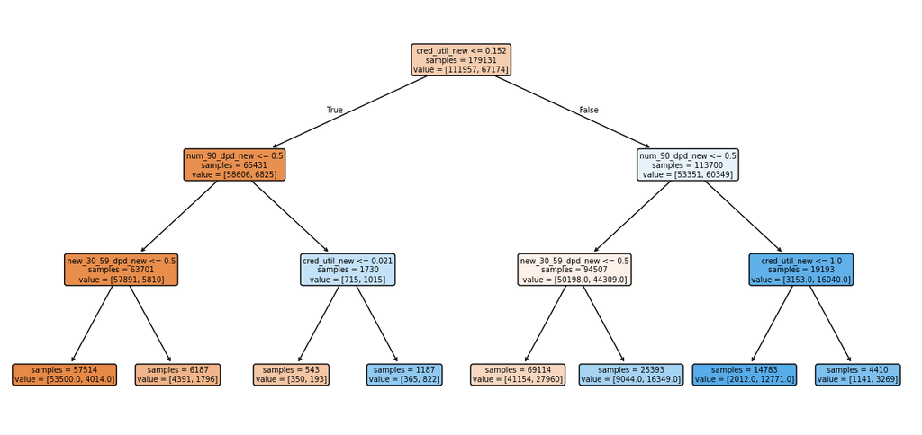

```python
# Plotting the model using train data
from sklearn.tree import plot_tree , export_text
plt.figure(figsize = (15,7))
plot_tree(Dtree2, filled = True , rounded = True , impurity = False , feature_names = list(X_train_smote.columns))
print( export_text(Dtree2, feature_names =list(X_train_smote.columns)))
```

```python
# Finding the accuracy of the model on train data
predict = Dtree2.predict(X_train_smote)

cm = confusion_matrix(y_train_smote,predict)
print(cm)

total = sum(sum(cm))
accuracy = (cm[0,0] + cm[1,1]) / total
print("Accuracy of the  model on train data= " , accuracy)
```

```
[[99395 12562]
 [33963 33211]]
Accuracy of the  model on train data=  0.7402738777765993
```

```python
sensitivity = (cm[0,0]) / (cm[0,0]+cm[0,1])
print("Sensitivity = " , sensitivity)

specificity = (cm[1,1]) / (cm[1,0] + cm[1,1])
print("Specificty = " , specificity)
```

```
Sensitivity =  0.8877962074725118
Specificty =  0.49440259624259386
```

```python
# Finding the accuracy of the model on test data
predict = Dtree2.predict(X_test)

cm = confusion_matrix(y_test,predict)
print(cm)

total = sum(sum(cm))
accuracy = (cm[0,0] + cm[1,1]) / total
print("Accuracy of the decision tree model on test data = " , accuracy)
```

```
[[24877  3140]
 [  844  1139]]
Accuracy of the decision tree model on test data =  0.8672
```

```python
sensitivity = (cm[0,0]) / (cm[0,0]+cm[0,1])
print("Sensitivity = " , sensitivity)

specificity = (cm[1,1]) / (cm[1,0] + cm[1,1])
print("Specificty = " , specificity)
```

```
Sensitivity =  0.8879251882785452
Specificty =  0.5743822491174987
```